# **EasyVisa — Predicting Visa Certification Outcomes**

### Full-Code Project Submission | AI & ML in Business Applications

## Context

Business communities in the United States are facing high demand for human resources, but one of the constant challenges is identifying and attracting the right talent, which is perhaps the most important element in remaining competitive. Companies in the United States look for hard-working, talented, and qualified individuals both locally as well as abroad.

The **Immigration and Nationality Act (INA)** of the US permits foreign workers to come to the United States to work on either a temporary or permanent basis. The act also protects US workers against adverse impacts on their wages or working conditions by ensuring US employers' compliance with statutory requirements when they hire foreign workers to fill workforce shortages. The immigration programs are administered by the **Office of Foreign Labor Certification (OFLC)**.

OFLC processes job certification applications for employers seeking to bring foreign workers into the United States and grants certifications in those cases where employers can demonstrate that there are not sufficient US workers available to perform the work at wages that meet or exceed the wage paid for the occupation in the area of intended employment.

## Objective

In FY 2016, the OFLC processed **775,979 employer applications** for **1,699,957 positions** — a nine percent increase over the previous year. Reviewing every case manually is becoming untenable as volumes grow.

OFLC has engaged **EasyVisa** to build a data-driven solution. As the data scientist on this engagement, the mandate is to use a **classification model** to:

1. **Facilitate the visa approval process** by pre-screening applications and routing them by predicted outcome.
2. **Recommend a suitable applicant profile** for whom the visa should be certified or denied, based on the drivers that significantly influence `case_status`.

### Framing this as a Machine Learning problem

| Element | Definition in this project |
| --- | --- |
| Task type | **Supervised binary classification** |
| Target | `case_status` — encoded as `Certified = 1`, `Denied = 0` |
| Unit of observation | One visa application |
| Features | 10 predictors describing the **employee** (continent, education, experience, training) and the **employer** (company size, year established, region, wage, wage unit, full-time flag) |
| Business use | A triage/shortlisting tool that flags applications likely to be certified so reviewer capacity is concentrated where it is needed |

### Choice of evaluation metric — and why it matters here

The two possible errors carry **different business costs**, so accuracy alone is inadequate:

- **False Positive** — model predicts *Certified*, the case is truly *Denied*. An unqualified application is waved through with light review. This is the more damaging error: it undermines the statutory protection of US workers' wages and working conditions, and exposes OFLC to compliance and audit risk.
- **False Negative** — model predicts *Denied*, the case is truly *Certified*. A qualified application is pushed into an unnecessary deep review. This wastes reviewer capacity and delays legitimate hiring, but the error is **recoverable** because a human reviewer still sees the case.

Because both errors are material and the classes are moderately imbalanced (roughly 2:1), we select **F1-score** as the primary metric — it is the harmonic mean of precision and recall and therefore penalises a model that buys recall by indiscriminately predicting *Certified*. **Recall** and **precision** are reported alongside so the precision/recall trade-off is visible, and accuracy is reported for completeness only.

> A useful benchmark to keep in mind: predicting *Certified* for every single application would score **66.8% accuracy** with zero analytical value. Any model must be judged against that naive baseline, not against zero.

## Data Description

The data contains the different attributes of the employee and the employer.

- **case_id**: ID of each visa application
- **continent**: Information of continent of the employee
- **education_of_employee**: Information of education of the employee
- **has_job_experience**: Does the employee have any job experience? Y = Yes; N = No
- **requires_job_training**: Does the employee require any job training? Y = Yes; N = No
- **no_of_employees**: Number of employees in the employer's company
- **yr_of_estab**: Year in which the employer's company was established
- **region_of_employment**: Foreign worker's intended region of employment in the US
- **prevailing_wage**: Average wage paid to similarly employed workers in a specific occupation in the area of intended employment. Its purpose is to ensure the foreign worker is not underpaid relative to comparable workers.
- **unit_of_wage**: Unit of prevailing wage — Hourly, Weekly, Monthly, Yearly
- **full_time_position**: Is the position full-time? Y = Full-Time; N = Part-Time
- **case_status**: Flag indicating if the visa was certified or denied — **target variable**

# **Importing necessary libraries**

```python
# Installing the libraries with the specified version.
!pip install numpy==2.0.2 pandas==2.2.2 scikit-learn==1.6.1 matplotlib==3.10.0 seaborn==0.13.2 xgboost==3.0.5 imbalanced-learn==0.13.0 -q --user
```

**Note**:

- After running the above cell, kindly restart the runtime (for Google Colab) or notebook kernel (for Jupyter Notebook), and run all cells sequentially from the next cell.
- On executing the above line of code, you might see a warning regarding package dependencies. This message can be ignored as the code above ensures all necessary libraries and their dependencies are maintained to successfully execute the code in **this notebook**.

```python
# ---------- Core data handling ----------
import numpy as np
import pandas as pd

# ---------- Visualisation ----------
import matplotlib.pyplot as plt
import seaborn as sns

# ---------- Splitting and tuning ----------
from sklearn.model_selection import train_test_split, RandomizedSearchCV

# ---------- Models: tree, bagging and boosting families ----------
from sklearn.tree import DecisionTreeClassifier, plot_tree
from sklearn.ensemble import (
    BaggingClassifier,
    RandomForestClassifier,
    AdaBoostClassifier,
    GradientBoostingClassifier,
)
from xgboost import XGBClassifier

# ---------- Metrics ----------
from sklearn.metrics import (
    accuracy_score,
    recall_score,
    precision_score,
    f1_score,
    confusion_matrix,
    classification_report,
)

# ---------- Class-imbalance handling ----------
from imblearn.over_sampling import SMOTE
from imblearn.under_sampling import RandomUnderSampler

# ---------- Display and warning settings ----------
import warnings
warnings.filterwarnings("ignore")

# display() renders DataFrames as formatted tables rather than plain text
from IPython.display import display

pd.set_option("display.max_columns", None)
pd.set_option("display.max_rows", 200)
pd.set_option("display.float_format", lambda x: "%.3f" % x)
sns.set_theme(style="whitegrid")

# ---------- Consistent figure sizing ----------
# Every figure is rendered at the same 10-inch width and 100 dpi, so all charts
# in the notebook are exactly 1000px wide and align cleanly down the page.
plt.rcParams["figure.figsize"] = (10, 5)
plt.rcParams["figure.dpi"] = 100
plt.rcParams["savefig.bbox"] = "standard"

# The inline backend passes bbox_inches="tight" explicitly, which overrides the
# rcParam above and crops each figure to its content — producing a different
# pixel width for every chart. Turning it off keeps widths uniform.
try:
    get_ipython().run_line_magic(
        "config", "InlineBackend.print_figure_kwargs = {'bbox_inches': None}"
    )
except Exception:
    pass

print("All libraries imported successfully.")
```

```
All libraries imported successfully.
```

# **Loading the dataset**

```python
# Mount Google Drive if running in Colab and the file is stored there.
# from google.colab import drive
# drive.mount('/content/drive')

# Read the dataset
visa = pd.read_csv("EasyVisa.csv")

# Work on a copy so the original raw data is always available for reference
data = visa.copy()

print("Dataset loaded. Shape:", data.shape)
```

```
Dataset loaded. Shape: (25480, 12)
```

# **Overview of the Dataset**

```python
# First five rows
data.head()
```

|  | case_id | continent | education_of_employee | has_job_experience | requires_job_training | no_of_employees | yr_of_estab | region_of_employment | prevailing_wage | unit_of_wage | full_time_position | case_status |
| --- | --- | --- | --- | --- | --- | --- | --- | --- | --- | --- | --- | --- |
| 0 | EZYV01 | Asia | High School | N | N | 14513 | 2007 | West | 592.203 | Hour | Y | Denied |
| 1 | EZYV02 | Asia | Master's | Y | N | 2412 | 2002 | Northeast | 83425.650 | Year | Y | Certified |
| 2 | EZYV03 | Asia | Bachelor's | N | Y | 44444 | 2008 | West | 122996.860 | Year | Y | Denied |
| 3 | EZYV04 | Asia | Bachelor's | N | N | 98 | 1897 | West | 83434.030 | Year | Y | Denied |
| 4 | EZYV05 | Africa | Master's | Y | N | 1082 | 2005 | South | 149907.390 | Year | Y | Certified |

```python
# Last five rows
data.tail()
```

|  | case_id | continent | education_of_employee | has_job_experience | requires_job_training | no_of_employees | yr_of_estab | region_of_employment | prevailing_wage | unit_of_wage | full_time_position | case_status |
| --- | --- | --- | --- | --- | --- | --- | --- | --- | --- | --- | --- | --- |
| 25475 | EZYV25476 | Asia | Bachelor's | Y | Y | 2601 | 2008 | South | 77092.570 | Year | Y | Certified |
| 25476 | EZYV25477 | Asia | High School | Y | N | 3274 | 2006 | Northeast | 279174.790 | Year | Y | Certified |
| 25477 | EZYV25478 | Asia | Master's | Y | N | 1121 | 1910 | South | 146298.850 | Year | N | Certified |
| 25478 | EZYV25479 | Asia | Master's | Y | Y | 1918 | 1887 | West | 86154.770 | Year | Y | Certified |
| 25479 | EZYV25480 | Asia | Bachelor's | Y | N | 3195 | 1960 | Midwest | 70876.910 | Year | Y | Certified |

```python
# Shape of the dataset
print("Number of rows    :", data.shape[0])
print("Number of columns :", data.shape[1])
```

```
Number of rows    : 25480
Number of columns : 12
```

```python
# Data types and non-null counts
data.info()
```

```
<class 'pandas.core.frame.DataFrame'>
RangeIndex: 25480 entries, 0 to 25479
Data columns (total 12 columns):
 #   Column                 Non-Null Count  Dtype
---  ------                 --------------  -----
 0   case_id                25480 non-null  object
 1   continent              25480 non-null  object
 2   education_of_employee  25480 non-null  object
 3   has_job_experience     25480 non-null  object
 4   requires_job_training  25480 non-null  object
 5   no_of_employees        25480 non-null  int64
 6   yr_of_estab            25480 non-null  int64
 7   region_of_employment   25480 non-null  object
 8   prevailing_wage        25480 non-null  float64
 9   unit_of_wage           25480 non-null  object
 10  full_time_position     25480 non-null  object
 11  case_status            25480 non-null  object
dtypes: float64(1), int64(2), object(9)
memory usage: 2.3+ MB
```

```python
# Statistical summary of the numerical columns
data.describe().T
```

|  | count | mean | std | min | 25% | 50% | 75% | max |
| --- | --- | --- | --- | --- | --- | --- | --- | --- |
| no_of_employees | 25480.000 | 5667.043 | 22877.929 | -26.000 | 1022.000 | 2109.000 | 3504.000 | 602069.000 |
| yr_of_estab | 25480.000 | 1979.410 | 42.367 | 1800.000 | 1976.000 | 1997.000 | 2005.000 | 2016.000 |
| prevailing_wage | 25480.000 | 74455.815 | 52815.942 | 2.137 | 34015.480 | 70308.210 | 107735.513 | 319210.270 |

```python
# Statistical summary of the categorical columns
data.describe(include=["object"]).T
```

|  | count | unique | top | freq |
| --- | --- | --- | --- | --- |
| case_id | 25480 | 25480 | EZYV25480 | 1 |
| continent | 25480 | 6 | Asia | 16861 |
| education_of_employee | 25480 | 4 | Bachelor's | 10234 |
| has_job_experience | 25480 | 2 | Y | 14802 |
| requires_job_training | 25480 | 2 | N | 22525 |
| region_of_employment | 25480 | 5 | Northeast | 7195 |
| unit_of_wage | 25480 | 4 | Year | 22962 |
| full_time_position | 25480 | 2 | Y | 22773 |
| case_status | 25480 | 2 | Certified | 17018 |

```python
# ---------- Sanity checks ----------
print("Missing values per column:")
print(data.isnull().sum())
print()
print("Number of fully duplicated rows :", data.duplicated().sum())
print("Unique case_id values           :", data["case_id"].nunique(), "out of", len(data))
print()
print("Negative values in no_of_employees :", (data["no_of_employees"] < 0).sum())
print("Minimum no_of_employees            :", data["no_of_employees"].min())
print()
print("Range of yr_of_estab :", data["yr_of_estab"].min(), "to", data["yr_of_estab"].max())
```

```
Missing values per column:
case_id                  0
continent                0
education_of_employee    0
has_job_experience       0
requires_job_training    0
no_of_employees          0
yr_of_estab              0
region_of_employment     0
prevailing_wage          0
unit_of_wage             0
full_time_position       0
case_status              0
dtype: int64

Number of fully duplicated rows : 0
Unique case_id values           : 25480 out of 25480

Negative values in no_of_employees : 33
Minimum no_of_employees            : -26

Range of yr_of_estab : 1800 to 2016
```

```python
# Unique values in each categorical column
for col in data.select_dtypes(include=["object"]).columns:
    if col != "case_id":
        print(f"{col} ({data[col].nunique()} levels):")
        print(data[col].value_counts())
        print("-" * 60)
```

```
continent (6 levels):
continent
Asia             16861
Europe            3732
North America     3292
South America      852
Africa             551
Oceania            192
Name: count, dtype: int64
------------------------------------------------------------
education_of_employee (4 levels):
education_of_employee
Bachelor's     10234
Master's        9634
High School     3420
Doctorate       2192
Name: count, dtype: int64
------------------------------------------------------------
has_job_experience (2 levels):
has_job_experience
Y    14802
N    10678
Name: count, dtype: int64
------------------------------------------------------------
requires_job_training (2 levels):
requires_job_training
N    22525
Y     2955
Name: count, dtype: int64
------------------------------------------------------------
region_of_employment (5 levels):
region_of_employment
Northeast    7195
South        7017
West         6586
Midwest      4307
Island        375
Name: count, dtype: int64
------------------------------------------------------------
unit_of_wage (4 levels):
unit_of_wage
Year     22962
Hour      2157
Week       272
Month       89
Name: count, dtype: int64
------------------------------------------------------------
full_time_position (2 levels):
full_time_position
Y    22773
N     2707
Name: count, dtype: int64
------------------------------------------------------------
case_status (2 levels):
case_status
Certified    17018
Denied        8462
Name: count, dtype: int64
------------------------------------------------------------
```

### Observations and sanity checks

**Structure**

- The dataset has **25,480 rows and 12 columns** — 3 numerical, 8 categorical, and 1 identifier (`case_id`).
- **No missing values** in any column, so no imputation strategy is required.
- **No duplicated rows**, and `case_id` has 25,480 unique values — one row per application, exactly as expected. `case_id` is a pure identifier with no predictive content and will be dropped before modelling.

**Data quality issues discovered**

1. **`no_of_employees` contains 33 negative values**, with a minimum of **-26**. A company cannot employ a negative number of people. This is a **data-entry error, not an outlier**, and must be corrected on its own merits — the distinction matters, because outliers are legitimate extreme observations while these values are simply invalid.
2. **`yr_of_estab` ranges from 1800 to 2016.** The very old years are plausible for long-established institutions, so they are treated as genuine rather than erroneous. The raw year is not directly meaningful to a model, so it is converted into **company age** during feature engineering.
3. **`prevailing_wage` is not on a consistent scale across `unit_of_wage`.** Rows marked *Hour* run from about $2 to $1,000, while rows marked *Week*, *Month* and *Year* all sit in the tens of thousands. This is examined in detail in the EDA and drives an explicit pre-processing decision.

**Target**

- `case_status` has two levels: **Certified (17,018 = 66.8%)** and **Denied (8,462 = 33.2%)** — a moderate imbalance of roughly **2:1**. Not severe, but strong enough that accuracy is a misleading metric and that we should test oversampled and undersampled variants of the training data.

# **Exploratory Data Analysis (EDA)**

The EDA below is organised in three layers:

1. **Univariate analysis** — the shape and spread of every variable on its own.
2. **Bivariate analysis** — how each predictor relates to `case_status`.
3. **Multivariate analysis** — how predictors interact with each other in shaping the outcome.

**Leading questions being answered:**

1. What is the distribution of visa case statuses (certified vs. denied)?
2. How does the education level of employees impact visa approval rates?
3. Is there a significant difference in visa approval rates between employees with and without prior job experience?
4. How does the prevailing wage affect visa approval? Do higher wages lead to higher chances of approval?
5. Do certain regions in the US have higher visa approval rates compared to others?
6. How does the number of employees in a company influence visa approval? Do larger companies have a higher approval rate?
7. Are visa approval rates different across various continents of employees? Which continent has the highest and lowest approval rates?

**Beyond the basics.** These seven questions are treated as a starting point rather than a checklist. The analysis below also examines: the internal consistency of `prevailing_wage` across wage units, the **non-additive interaction** between education and job experience, whether **continent is an independent driver or a proxy** for applicant qualifications, the region × education interaction, and which predictors carry **no usable signal at all**. Several of these turn out to matter more than the guiding questions suggest — and two widely held assumptions are refuted outright.

## Helper functions for visualisation

```python
def histogram_boxplot(df, feature, figsize=(10, 5), kde=False, bins=None):
    """
    Draw a boxplot and a histogram on the same x-axis for a numerical feature.

    The boxplot sits on top so outliers and the median line can be read directly
    against the shape of the distribution below it.
    """
    fig, (ax_box, ax_hist) = plt.subplots(
        nrows=2, sharex=True, gridspec_kw={"height_ratios": (0.25, 0.75)}, figsize=figsize
    )
    sns.boxplot(data=df, x=feature, ax=ax_box, showmeans=True, color="violet")
    sns.histplot(data=df, x=feature, kde=kde, ax=ax_hist, bins=bins, color="steelblue")
    # Mean (dashed) and median (solid) reference lines
    ax_hist.axvline(df[feature].mean(), color="green", linestyle="--", label="Mean")
    ax_hist.axvline(df[feature].median(), color="black", linestyle="-", label="Median")
    ax_hist.legend()
    ax_box.set(xlabel="")
    plt.suptitle(f"Distribution of {feature}", fontsize=13)
    plt.tight_layout()
    plt.show()


def labeled_barplot(df, feature, perc=False, n=None):
    """
    Bar plot of the value counts of a categorical feature, with the count or
    percentage printed above each bar.
    """
    total = len(df[feature])
    count = df[feature].nunique()
    plt.figure(figsize=(10, 4.5))
    plt.xticks(rotation=30, ha="right")
    ax = sns.countplot(
        data=df, x=feature, palette="Paired",
        order=df[feature].value_counts().index[:n],
    )
    for p in ax.patches:
        label = f"{100 * p.get_height() / total:.1f}%" if perc else int(p.get_height())
        ax.annotate(label, (p.get_x() + p.get_width() / 2, p.get_height()),
                    ha="center", va="center", size=10, xytext=(0, 7),
                    textcoords="offset points")
    plt.title(f"Count of {feature}", fontsize=12)
    plt.tight_layout()
    plt.show()


def stacked_barplot(df, predictor, target="case_status"):
    """
    Stacked bar chart of the target proportions within each level of a predictor.

    Proportions rather than raw counts are plotted, because the levels have very
    different sizes and only the *rate* of certification is comparable across them.
    """
    count = df[predictor].nunique()
    tab_counts = pd.crosstab(df[predictor], df[target], margins=True).sort_values(
        by="All", ascending=False
    )
    print(tab_counts)
    print("-" * 60)
    tab = pd.crosstab(df[predictor], df[target], normalize="index").sort_values(
        by=df[target].unique()[0], ascending=False
    )
    tab.plot(kind="bar", stacked=True, figsize=(10, 5))
    plt.legend(loc="lower left", frameon=True)
    plt.ylabel("Proportion of applications")
    plt.title(f"{target} proportion by {predictor}", fontsize=12)
    plt.xticks(rotation=30, ha="right")
    plt.tight_layout()
    plt.show()


def distribution_plot_wrt_target(df, predictor, target="case_status"):
    """Boxplot and histogram of a numerical predictor split by the target class."""
    fig, axs = plt.subplots(1, 2, figsize=(10, 4.5))
    sns.boxplot(data=df, x=target, y=predictor, ax=axs[0], palette="Set2", showmeans=True)
    axs[0].set_title(f"{predictor} by {target}")
    sns.histplot(data=df, x=predictor, hue=target, kde=True, ax=axs[1],
                 palette="Set2", element="step", stat="density", common_norm=False)
    axs[1].set_title(f"{predictor} density by {target}")
    plt.tight_layout()
    plt.show()

print("Visualisation helpers defined.")
```

```
Visualisation helpers defined.
```

## Univariate Analysis

### Target variable — `case_status`

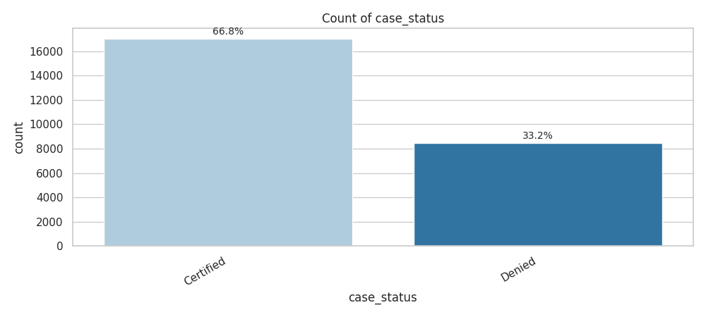

```
case_status
Certified    17018
Denied        8462
Name: count, dtype: int64

case_status
Certified   66.790
Denied      33.210
Name: proportion, dtype: float64
```

```python
labeled_barplot(data, "case_status", perc=True)

print(data["case_status"].value_counts())
print()
print(data["case_status"].value_counts(normalize=True).round(4) * 100)
```

**Observation — Leading Question 1**

- **66.8% of applications are Certified** and **33.2% are Denied** — an imbalance of roughly **2:1**.
- The imbalance is **moderate, not severe**. It does not require aggressive resampling, but it does mean:
  - **Accuracy is misleading** — a model that blindly predicts *Certified* for everyone scores 66.8% while learning nothing. This is the naive baseline every model must beat.
  - Building the models on **oversampled** and **undersampled** training data (later sections) is worth testing to see whether balancing the classes materially improves the recovery of *Denied* cases.

### Numerical variables

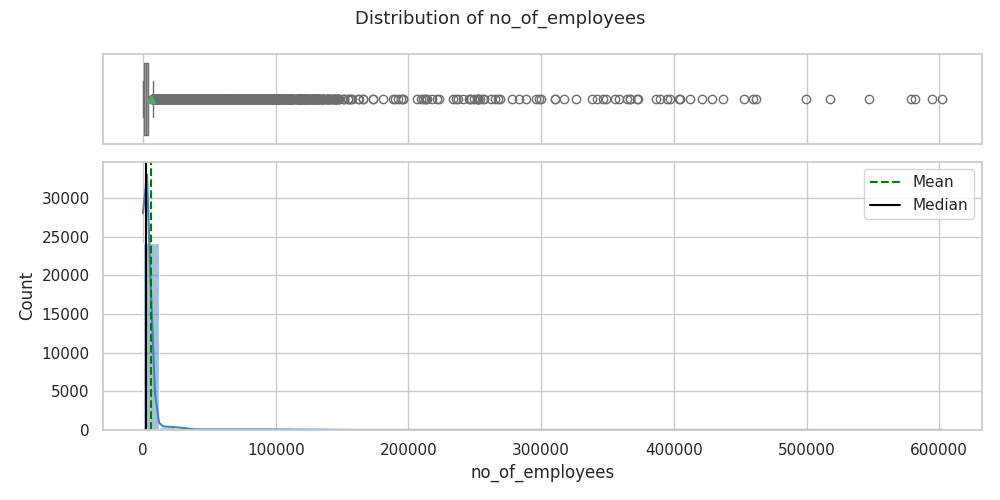

```python
histogram_boxplot(data, "no_of_employees", kde=True, bins=50)
```

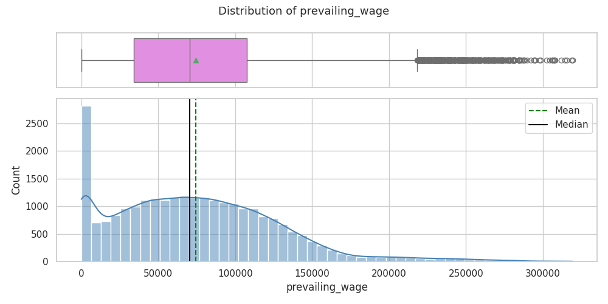

```python
histogram_boxplot(data, "prevailing_wage", kde=True, bins=50)
```

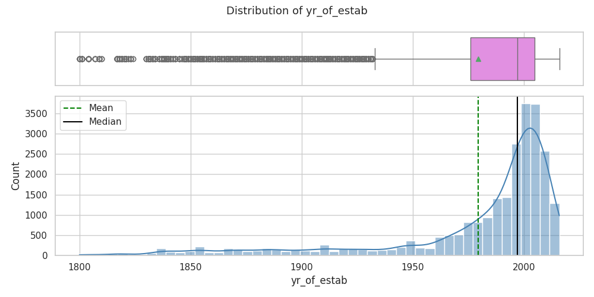

```python
histogram_boxplot(data, "yr_of_estab", kde=True, bins=50)
```

**Observations on the numerical variables**

- **`no_of_employees`** is **extremely right-skewed**. The median company has roughly 2,100 employees while the maximum is **602,069**, and the mean (5,667) sits far above the median — the classic signature of a long right tail. The boxplot flags a large number of high-side points. Crucially, this variable also contains the **33 negative values** already identified, which are invalid rather than extreme.
- **`prevailing_wage`** is right-skewed with a **distinct spike very close to zero**. That spike is *not* a data error — it is the block of rows whose `unit_of_wage` is *Hour*, where the value is an hourly rate rather than an annual salary. This is confirmed below and is the single most important structural feature of this dataset.
- **`yr_of_estab`** is **strongly left-skewed**: the bulk of employers were founded after about 1980, with a thin tail of long-established institutions stretching back to 1800. Raw calendar year is not a natural model input, so it is converted to **company age** in pre-processing.

```python
# Confirming the near-zero prevailing_wage spike is driven by unit_of_wage
print("Distribution of prevailing_wage within each unit_of_wage:")
print(data.groupby("unit_of_wage")["prevailing_wage"].describe().round(1))
print()
print("Rows with prevailing_wage below $1,000, broken down by unit_of_wage:")
print(data.loc[data["prevailing_wage"] < 1000, "unit_of_wage"].value_counts())
```

```
Distribution of prevailing_wage within each unit_of_wage:
                 count      mean       std      min       25%       50%  \
unit_of_wage
Hour          2157.000   414.600   275.000    2.100   152.700   372.700
Month           89.000 87592.900 59525.100 1599.300 44986.200 81826.000
Week           272.000 85606.800 44802.700 2183.200 51408.300 85075.800
Year         22962.000 81228.100 49951.500  100.000 43716.000 76174.500

                    75%        max
unit_of_wage
Hour            637.300    999.900
Month        121629.600 264363.000
Week         111331.900 280176.000
Year         111342.000 319210.300

Rows with prevailing_wage below $1,000, broken down by unit_of_wage:
unit_of_wage
Hour    2157
Year     110
Name: count, dtype: int64
```

**Key structural finding — the `prevailing_wage` scale is inconsistent**

| `unit_of_wage` | rows | median `prevailing_wage` |
| --- | --- | --- |
| Hour | 2,157 | ≈ **373** |
| Week | 272 | ≈ 85,076 |
| Month | 89 | ≈ 81,826 |
| Year | 22,962 | ≈ 76,175 |

Almost every row with a wage below $1,000 is an **Hour** row. But notice what happens if we take the units at face value and annualise: *Week* would become 85,076 × 52 ≈ **$4.4 million** and *Month* would become 81,826 × 12 ≈ **$1.0 million** per year. Both are absurd.

The correct reading is therefore that **only the Hour rows are on a genuinely different scale**; the Week, Month and Year rows are already recorded at annual-equivalent magnitudes despite their labels. This finding directly determines the pre-processing decision on wage, discussed in the *Feature engineering* section — and it is the reason a naive `prevailing_wage × 52 / × 12` conversion would corrupt the data rather than clean it.

### Categorical variables

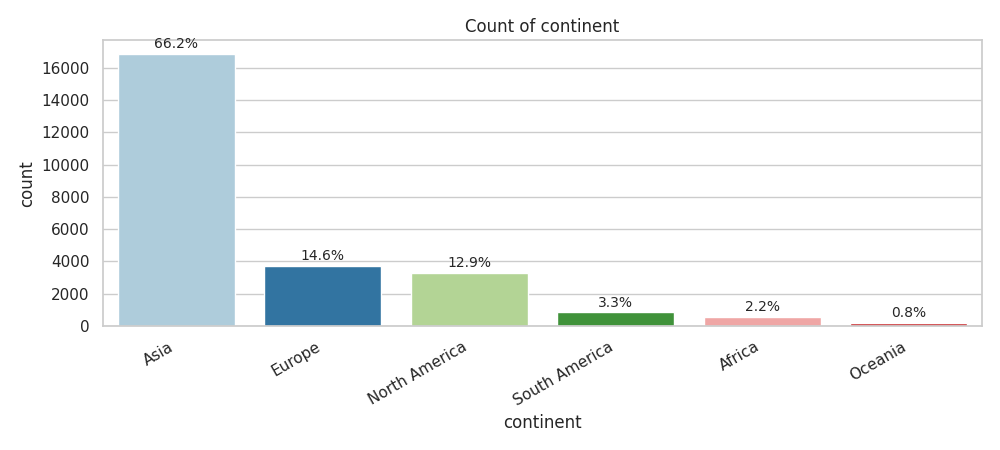

```python
labeled_barplot(data, "continent", perc=True)
```

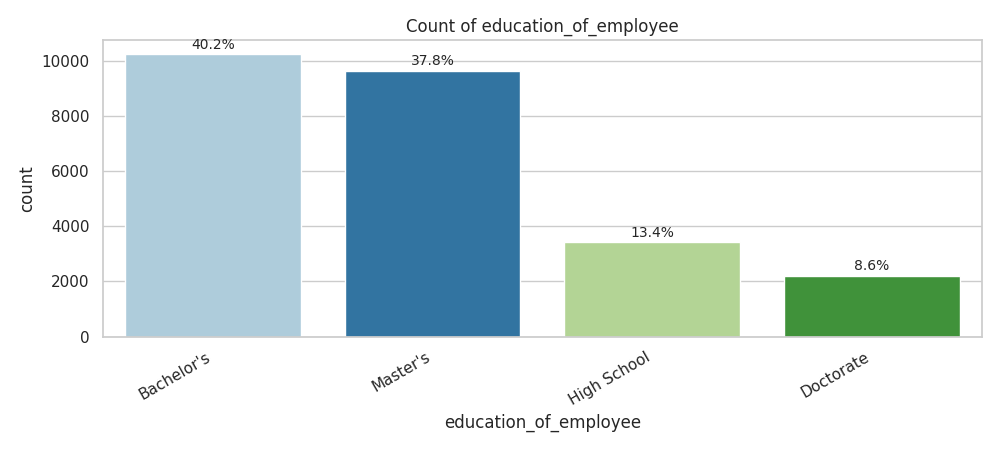

```python
labeled_barplot(data, "education_of_employee", perc=True)
```

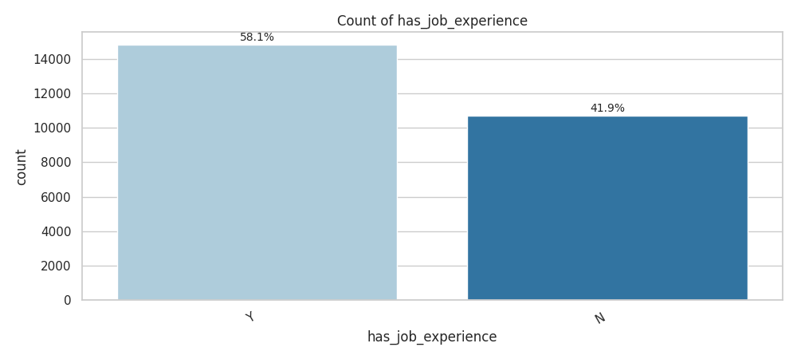

```python
labeled_barplot(data, "has_job_experience", perc=True)
```

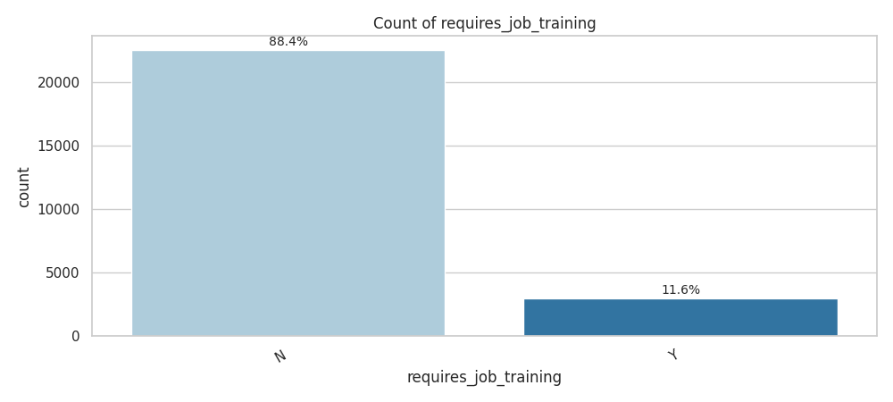

```python
labeled_barplot(data, "requires_job_training", perc=True)
```

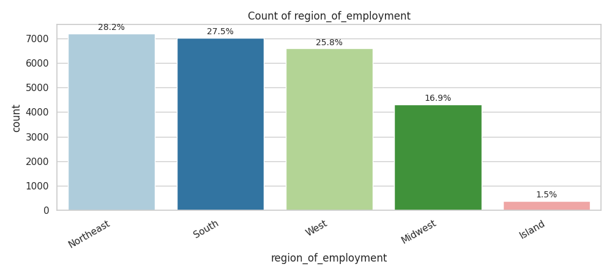

```python
labeled_barplot(data, "region_of_employment", perc=True)
```

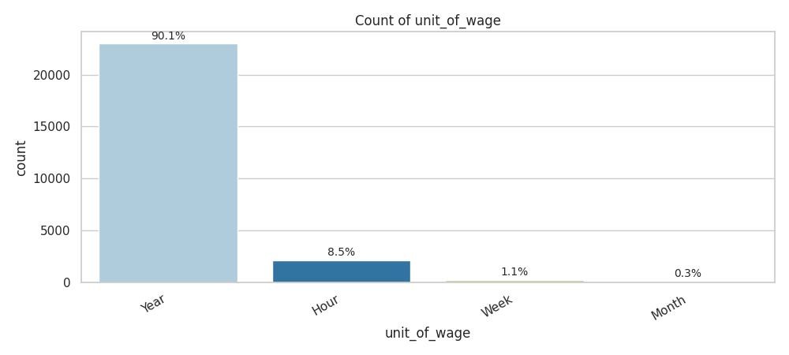

```python
labeled_barplot(data, "unit_of_wage", perc=True)
```

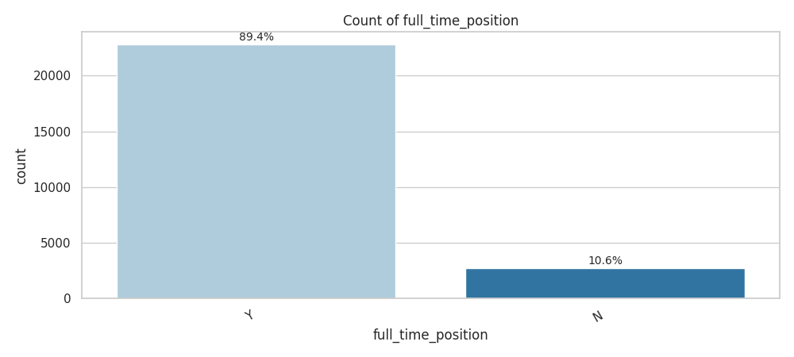

```python
labeled_barplot(data, "full_time_position", perc=True)
```

**Observations on the categorical variables**

- **`continent`** is heavily concentrated: **Asia accounts for 66.2%** (16,861 applications), followed by Europe (14.6%) and North America (12.9%). Oceania (192) and Africa (551) are very thin — rate estimates for those levels rest on small samples and should be read with caution.
- **`education_of_employee`** is reasonably spread: Bachelor's 40.2%, Master's 37.8%, High School 13.4%, Doctorate 8.6%.
- **`has_job_experience`** — 58.1% of applicants have prior experience, 41.9% do not. A well-balanced and, as we will see, highly informative split.
- **`requires_job_training`** is very lopsided: only **11.6%** require training.
- **`region_of_employment`** — Northeast (28.2%), South (27.5%), West (25.8%) and Midwest (16.9%) dominate; Island is marginal at 1.5%.
- **`unit_of_wage`** — **90.1% Year**, 8.5% Hour, and Week/Month together under 1.5%.
- **`full_time_position`** — **89.4% are full-time**, leaving only 10.6% part-time.

Several variables are therefore dominated by a single level (`unit_of_wage`, `full_time_position`, `requires_job_training`). Low-variance predictors like these tend to contribute little to a tree-based model, and the feature-importance analysis at the end confirms exactly that.

## Bivariate Analysis

Each predictor is now examined against `case_status`. For the categorical predictors the **certification rate** within each level is what matters, so proportions rather than raw counts are plotted.

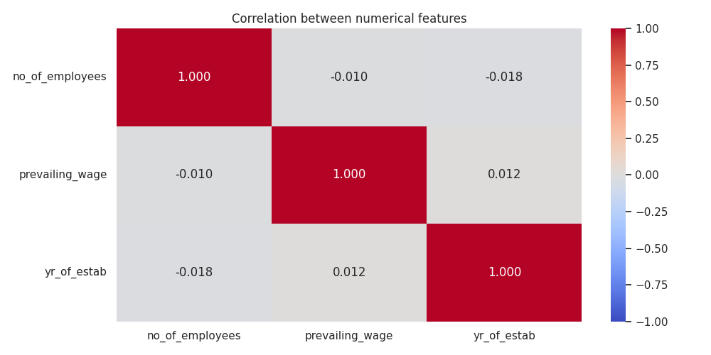

```python
# Correlation heatmap of the numerical features
plt.figure(figsize=(10, 5))
num_cols = ["no_of_employees", "prevailing_wage", "yr_of_estab"]
sns.heatmap(data[num_cols].corr(), annot=True, fmt=".3f", cmap="coolwarm",
            vmin=-1, vmax=1)
plt.title("Correlation between numerical features", fontsize=12)
plt.tight_layout()
plt.show()
```

**Observation**

All pairwise correlations among the numerical features are **effectively zero** (|r| < 0.02). There is no multicollinearity to resolve, and each numerical variable carries independent information. This also tells us that company size, wage level and year of establishment vary independently of one another in this dataset.

```
case_status            Certified  Denied    All
education_of_employee
All                        17018    8462  25480
Bachelor's                  6367    3867  10234
Master's                    7575    2059   9634
High School                 1164    2256   3420
Doctorate                   1912     280   2192
------------------------------------------------------------
```

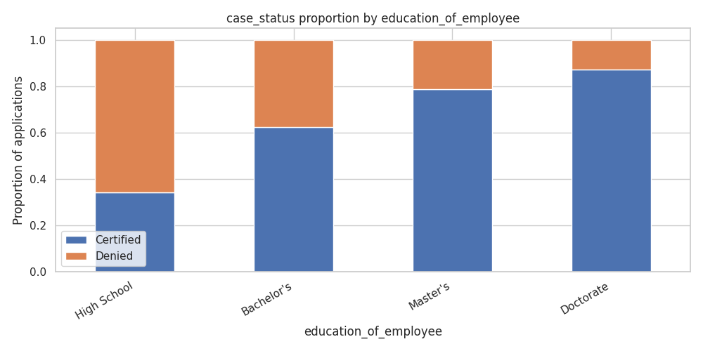

```python
stacked_barplot(data, "education_of_employee")
```

**Observation — Leading Question 2: education is the strongest single driver**

Certification rate rises **monotonically and steeply** with education:

| Education | Applications | Certification rate |
| --- | --- | --- |
| Doctorate | 2,192 | **87.2%** |
| Master's | 9,634 | **78.6%** |
| Bachelor's | 10,234 | **62.2%** |
| High School | 3,420 | **34.0%** |

The spread from High School to Doctorate is **53 percentage points** — by far the widest of any predictor in the dataset. High School applicants are the only group where **denial is the majority outcome (66.0%)**, meaning the default expectation flips entirely for that segment.

This is consistent with the statutory logic of the programme: certification requires demonstrating that sufficient US workers are *not* available, which is far easier to establish for specialised, advanced-degree roles than for roles requiring only a high-school education. **We should expect education to dominate feature importance**, and it does.

```
case_status         Certified  Denied    All
has_job_experience
All                     17018    8462  25480
Y                       11024    3778  14802
N                        5994    4684  10678
------------------------------------------------------------
```

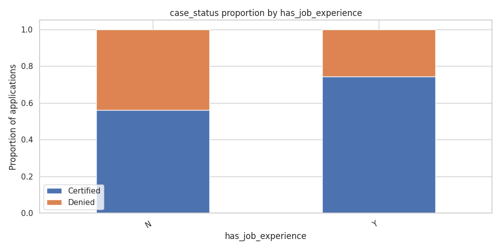

```python
stacked_barplot(data, "has_job_experience")
```

**Observation — Leading Question 3: yes, experience matters substantially**

- With prior experience: **74.5% certified** (14,802 applications)
- Without prior experience: **56.1% certified** (10,678 applications)

```
case_status    Certified  Denied    All
continent
All                17018    8462  25480
Asia               11012    5849  16861
Europe              2957     775   3732
North America       2037    1255   3292
South America        493     359    852
Africa               397     154    551
Oceania              122      70    192
------------------------------------------------------------
```

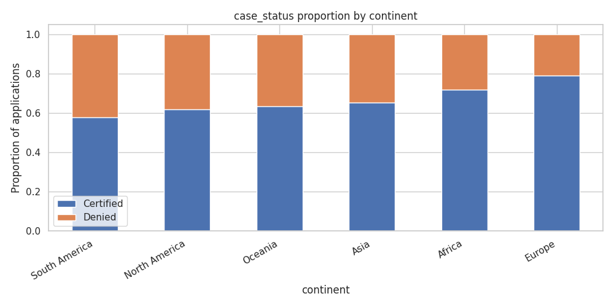

```python
stacked_barplot(data, "continent")
```

**Observation — Leading Question 7: yes, approval rates differ across continents**

| Continent | Applications | Certification rate |
| --- | --- | --- |
| **Europe** | 3,732 | **79.2% ← highest** |
| Africa | 551 | 72.1% |
| Asia | 16,861 | 65.3% |
| Oceania | 192 | 63.5% |
| North America | 3,292 | 61.9% |
| **South America** | 852 | **57.9% ← lowest** |

**Europe has the highest approval rate at 79.2%; South America the lowest at 57.9%** — a spread of about **21 percentage points**.

Note the counter-intuitive pattern: **Asia submits 66.2% of all applications (16,861) but certifies at only 65.3%**, below the overall base rate. Volume and success rate are unrelated. Europe submits a fifth as many applications yet certifies at a far higher rate.

```
case_status           Certified  Denied    All
region_of_employment
All                       17018    8462  25480
Northeast                  4526    2669   7195
South                      4913    2104   7017
West                       4100    2486   6586
Midwest                    3253    1054   4307
Island                      226     149    375
------------------------------------------------------------
```

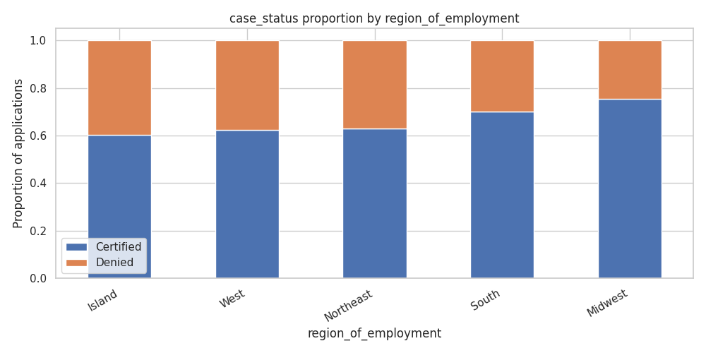

```python
stacked_barplot(data, "region_of_employment")
```

**Observation — Leading Question 5: modest but real regional variation**

| Region | Applications | Certification rate |
| --- | --- | --- |
| Midwest | 4,307 | **75.5%** |
| South | 7,017 | 70.0% |
| Northeast | 7,195 | 62.9% |
| West | 6,586 | 62.3% |
| Island | 375 | 60.3% |

The **Midwest is the most favourable region at 75.5%**, roughly **13 points above the West and Northeast** — even though those two regions receive far more applications. A plausible reading is that labour markets in the Midwest are less saturated with qualified domestic candidates in the relevant occupations, making the "no sufficient US workers available" test easier to satisfy. The West and Northeast are the large, competitive tech and finance corridors where that test is harder to meet.

```
case_status   Certified  Denied    All
unit_of_wage
All               17018    8462  25480
Year              16047    6915  22962
Hour                747    1410   2157
Week                169     103    272
Month                55      34     89
------------------------------------------------------------
```

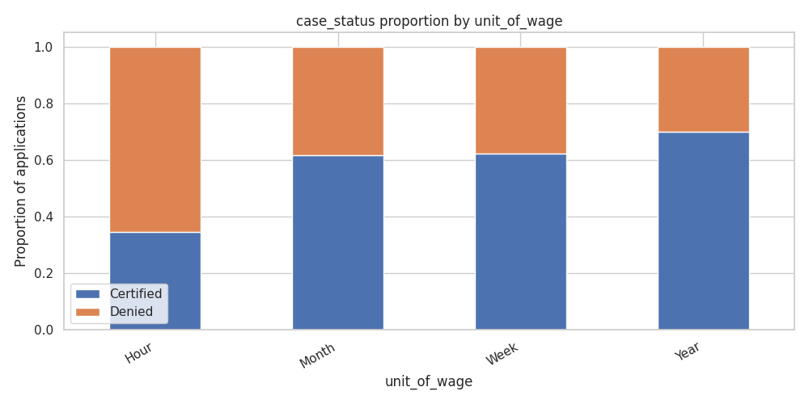

```python
stacked_barplot(data, "unit_of_wage")
```

**Observation — `unit_of_wage` is a powerful proxy for job type**

| Unit | Applications | Certification rate |
| --- | --- | --- |
| Year | 22,962 | **69.9%** |
| Week | 272 | 62.1% |
| Month | 89 | 61.8% |
| Hour | 2,157 | **34.6%** |

**Hourly-paid positions are certified only 34.6% of the time versus 69.9% for salaried positions** — a gap of over **35 points**, the second-largest effect in the entire dataset after education.

```
case_status            Certified  Denied    All
requires_job_training
All                        17018    8462  25480
N                          15012    7513  22525
Y                           2006     949   2955
------------------------------------------------------------
```

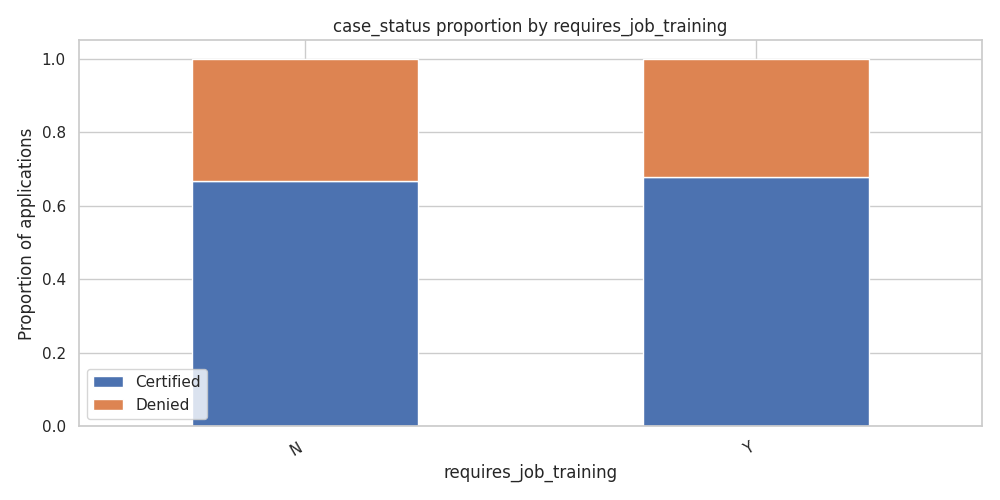

```python
stacked_barplot(data, "requires_job_training")
```

```
case_status         Certified  Denied    All
full_time_position
All                     17018    8462  25480
Y                       15163    7610  22773
N                        1855     852   2707
------------------------------------------------------------
```

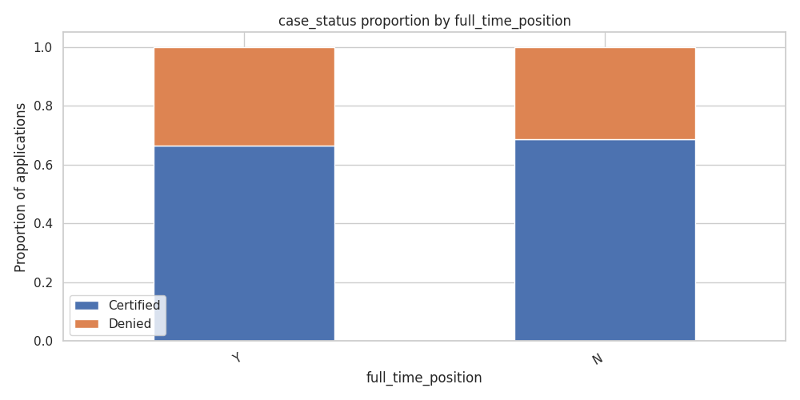

```python
stacked_barplot(data, "full_time_position")
```

**Observation — two predictors with essentially no signal**

- **`requires_job_training`**: 67.9% certified when training is required vs 66.7% when it is not — a difference of **1.2 points**.
- **`full_time_position`**: 66.6% certified for full-time vs 68.5% for part-time — a difference of **1.9 points**, and in the *opposite* direction to intuition.

Both gaps are negligible and neither variable meaningfully separates the classes. We **retain** them for modelling (tree ensembles are robust to uninformative features, and removing them risks discarding weak interaction effects), but we should expect both to rank near the bottom of feature importance — and they do. Recognising uninformative predictors early is as valuable as finding strong ones: it tells the business which fields are *not* worth investing in.

### Numerical predictors versus the target

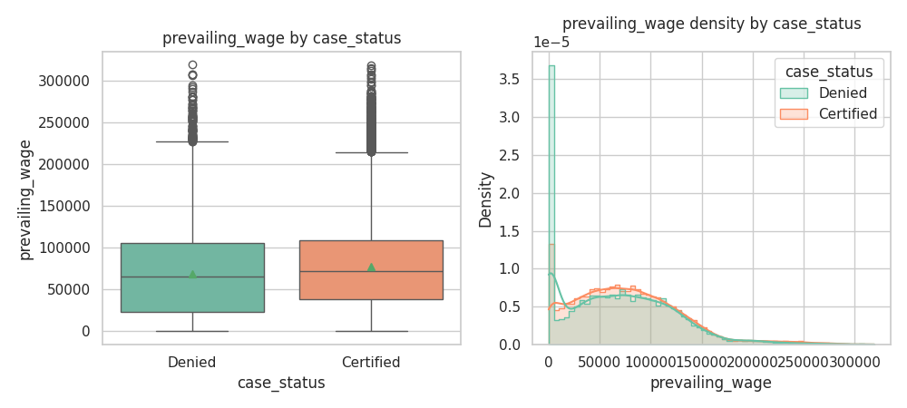

```python
distribution_plot_wrt_target(data, "prevailing_wage")
```

```python
# Certification rate across wage quartiles, restricted to salaried (Year) rows only.
# Restricting to a single unit is essential -- mixing Hour rows into wage quartiles
# would conflate "low wage" with "hourly job type" and produce a spurious result.
yearly = data[data["unit_of_wage"] == "Year"].copy()
yearly["wage_quartile"] = pd.qcut(yearly["prevailing_wage"], 4,
                                  labels=["Q1 (lowest)", "Q2", "Q3", "Q4 (highest)"])
wage_tab = pd.crosstab(yearly["wage_quartile"], yearly["case_status"],
                       normalize="index").round(4) * 100
wage_tab["n"] = yearly["wage_quartile"].value_counts().sort_index()
print("Certification rate by wage quartile (salaried / 'Year' rows only):")
print(wage_tab)
```

```
Certification rate by wage quartile (salaried / 'Year' rows only):
case_status    Certified  Denied     n
wage_quartile
Q1 (lowest)       71.560  28.440  5741
Q2                69.810  30.190  5740
Q3                69.490  30.510  5740
Q4 (highest)      68.680  31.320  5741
```

**Observation — Leading Question 4: higher wages do NOT improve approval odds**

This is a **counter-intuitive but important finding**. Within salaried applications, the certification rate is essentially **flat across wage quartiles**:

| Wage quartile (Year rows) | Certification rate |
| --- | --- |
| Q1 — lowest | 71.6% |
| Q2 | 69.8% |
| Q3 | 69.5% |
| Q4 — highest | 68.7% |

The rate drifts *down* by under 3 points from the lowest to the highest quartile — no practical effect, and if anything the opposite of the expected direction.

**Why this makes sense:** the prevailing wage is a **regulatory floor, not a measure of merit**. Its statutory purpose is to confirm the foreign worker is not underpaid relative to comparable local workers. Once an application clears that floor, paying more confers no additional advantage. The earlier appearance of a strong wage effect in the raw distribution plot was entirely an artefact of the Hour rows sitting on a different numeric scale — a textbook example of why segmenting before interpreting matters.

**Business implication:** advising employers to inflate offered wages to improve certification odds would be **actively wrong advice**. The lever is the *nature of the role and the candidate's qualifications*, not the salary figure.

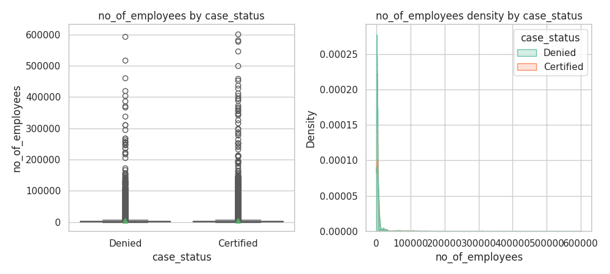

```python
distribution_plot_wrt_target(data, "no_of_employees")
```

```python
# Certification rate across company-size quartiles
data["emp_quartile"] = pd.qcut(data["no_of_employees"].abs(), 4,
                               labels=["Q1 (smallest)", "Q2", "Q3", "Q4 (largest)"])
emp_tab = pd.crosstab(data["emp_quartile"], data["case_status"],
                      normalize="index").round(4) * 100
emp_tab["n"] = data["emp_quartile"].value_counts().sort_index()
print("Certification rate by company-size quartile:")
print(emp_tab)
data.drop(columns=["emp_quartile"], inplace=True)
```

```
Certification rate by company-size quartile:
case_status    Certified  Denied     n
emp_quartile
Q1 (smallest)     65.920  34.080  6376
Q2                65.610  34.390  6368
Q3                66.040  33.960  6369
Q4 (largest)      69.590  30.410  6367
```

```python
# Certification rate across company-age quartiles
data["company_age_tmp"] = 2016 - data["yr_of_estab"]
data["age_quartile"] = pd.qcut(data["company_age_tmp"], 4,
                               labels=["Q1 (youngest)", "Q2", "Q3", "Q4 (oldest)"])
age_tab = pd.crosstab(data["age_quartile"], data["case_status"],
                      normalize="index").round(4) * 100
age_tab["n"] = data["age_quartile"].value_counts().sort_index()
print("Certification rate by company-age quartile:")
print(age_tab)
data.drop(columns=["company_age_tmp", "age_quartile"], inplace=True)
```

```
Certification rate by company-age quartile:
case_status    Certified  Denied     n
age_quartile
Q1 (youngest)     69.440  30.560  6751
Q2                65.460  34.540  6483
Q3                65.690  34.310  5920
Q4 (oldest)       66.350  33.650  6326
```

**Observation — Leading Question 6: employer characteristics barely matter**

- **Company size**: the three smaller quartiles are **statistically indistinguishable** — 65.9%, 65.6% and 66.0%, all sitting on the 66.8% base rate. Only the largest quartile edges up, to **69.6%**. So the honest reading is that company size has **almost no effect across most of the range**, with at most a **3.7-point** advantage confined to the very largest employers. The boxplot confirms the distributions of `no_of_employees` for Certified and Denied cases are nearly indistinguishable. This is a marginal effect, not a driver.
- **Company age**: the youngest quartile (0–11 years) certifies at **69.4%** versus roughly **65.5–66.3%** for the older quartiles — a spread of about 4 points. Directionally interesting, practically minor.

**Conclusion across both:** `case_status` is driven overwhelmingly by **employee attributes** (education, experience) and **job characteristics** (wage unit, region), and only marginally by **employer attributes** (size, age). This is a meaningful insight for the business — it means the model's recommendations should focus on candidate and role profiles, and that OFLC's review effort need not be stratified by company size.

## Multivariate Analysis

The bivariate results raise a specific question: are the observed effects **independent**, or are some variables merely proxies for others? The analysis below tests the interactions that matter most.

```python
# Interaction: education x job experience
edu_exp = pd.crosstab([data["education_of_employee"], data["has_job_experience"]],
                      data["case_status"], normalize="index").round(4) * 100
edu_exp["n"] = data.groupby(["education_of_employee", "has_job_experience"]).size()
print("Certification rate by education AND job experience:")
print(edu_exp)
```

```
Certification rate by education AND job experience:
case_status                               Certified  Denied     n
education_of_employee has_job_experience
Bachelor's            N                      51.310  48.690  4348
                      Y                      70.270  29.730  5886
Doctorate             N                      80.130  19.870   941
                      Y                      92.570   7.430  1251
High School           N                      31.660  68.340  1396
                      Y                      35.670  64.330  2024
Master's              N                      64.290  35.710  3993
                      Y                      88.780  11.220  5641
```

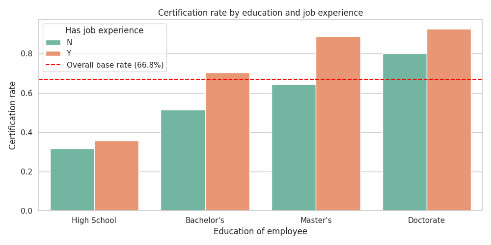

```python
# Same interaction, visualised
plt.figure(figsize=(10, 5))
sns.barplot(data=data.assign(certified=(data["case_status"] == "Certified").astype(int)),
            x="education_of_employee", y="certified", hue="has_job_experience",
            palette="Set2", errorbar=None,
            order=["High School", "Bachelor's", "Master's", "Doctorate"])
plt.axhline(0.668, color="red", linestyle="--", label="Overall base rate (66.8%)")
plt.ylabel("Certification rate")
plt.xlabel("Education of employee")
plt.title("Certification rate by education and job experience", fontsize=12)
plt.legend(title="Has job experience")
plt.tight_layout()
plt.show()
```

**Observation — education and experience combine into a powerful, and non-additive, signal**

| Education | No experience | Has experience | Lift from experience |
| --- | --- | --- | --- |
| Doctorate | 80.1% | **92.6%** | +12.5 pts |
| Master's | 64.3% | **88.8%** | **+24.5 pts** |
| Bachelor's | 51.3% | 70.3% | +19.0 pts |
| High School | 31.7% | 35.7% | **+4.0 pts** |

Three findings of real business value here:

1. **The range is enormous.** From *High School without experience* at **31.7%** to *Doctorate with experience* at **92.6%** — a **61-point spread**. These two variables alone separate the population into segments with almost opposite expected outcomes.
2. **The interaction is not additive — experience pays off very differently by education level.** It adds **+24.5 points** for a Master's candidate but only **+4.0 points** for a High School candidate. Experience amplifies an already-credible profile; it cannot rescue a weak one. This is precisely the kind of non-linear interaction that **tree-based ensembles capture natively** and a linear model would miss — a solid justification for the model family chosen in this project.
3. **Doctorate holders are near-certain at 92.6% with experience**, making this the clearest candidate segment for fast-track processing.

```python
# Is continent an independent driver, or a proxy for education?
print("Education mix within each continent (row %):")
print((pd.crosstab(data["continent"], data["education_of_employee"],
                   normalize="index").round(4) * 100))
print()
print("Certification rate by continent, holding education constant:")
print((pd.crosstab(data["education_of_employee"], data["continent"],
                   values=(data["case_status"] == "Certified").astype(int),
                   aggfunc="mean").round(3) * 100))
```

```
Education mix within each continent (row %):
education_of_employee  Bachelor's  Doctorate  High School  Master's
continent
Africa                     25.950      9.800       11.980    52.270
Asia                       42.510      5.470       13.580    38.430
Europe                     34.810     22.670       13.130    29.390
North America              37.210      7.840       12.180    42.770
Oceania                    34.380     11.460       18.750    35.420
South America              39.080     10.450       16.080    34.390

Certification rate by continent, holding education constant:
continent              Africa   Asia  Europe  North America  Oceania  \
education_of_employee
Bachelor's             56.600 61.500  80.100         52.300   57.600
Doctorate              79.600 84.500  93.100         80.200   86.400
High School            34.800 29.500  33.100         52.400   52.800
Master's               86.800 79.500  88.100         69.500   67.600

continent              South America
education_of_employee
Bachelor's                    48.000
Doctorate                     84.300
High School                   54.000
Master's                      62.800
```

```python
# Wage-unit x education: are hourly and low-education segments the same population?
print("Certification rate by unit_of_wage and education (%):")
print((pd.crosstab(data["unit_of_wage"], data["education_of_employee"],
                   values=(data["case_status"] == "Certified").astype(int),
                   aggfunc="mean").round(3) * 100))
print()
print("Row counts:")
print(pd.crosstab(data["unit_of_wage"], data["education_of_employee"]))
```

```
Certification rate by unit_of_wage and education (%):
education_of_employee  Bachelor's  Doctorate  High School  Master's
unit_of_wage
Hour                       28.400     60.400       24.800    45.500
Month                      63.400     80.000       46.200    63.300
Week                       57.900     75.000       43.800    71.700
Year                       65.900     88.500       35.100    81.300

Row counts:
education_of_employee  Bachelor's  Doctorate  High School  Master's
unit_of_wage
Hour                          981         96          395       685
Month                          41          5           13        30
Week                          126          8           32       106
Year                         9086       2083         2980      8813
```

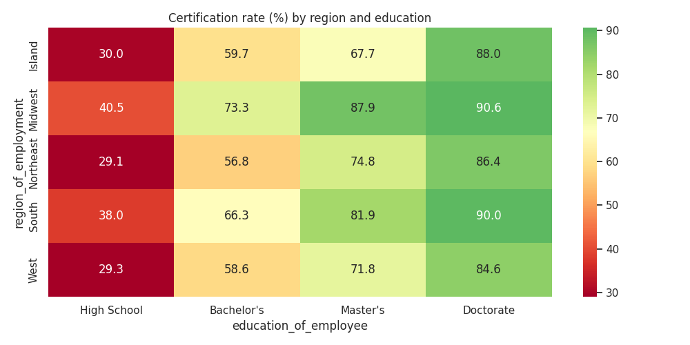

```python
# Region x education interaction
plt.figure(figsize=(10, 5))
region_edu = (pd.crosstab(data["region_of_employment"], data["education_of_employee"],
                          values=(data["case_status"] == "Certified").astype(int),
                          aggfunc="mean") * 100)
sns.heatmap(region_edu[["High School", "Bachelor's", "Master's", "Doctorate"]],
            annot=True, fmt=".1f", cmap="RdYlGn", center=66.8)
plt.title("Certification rate (%) by region and education", fontsize=12)
plt.tight_layout()
plt.show()
```

**Observation — the region effect survives, but education dominates within every region**

The heatmap shows two things at once:

- **Reading across each row** (within a region), the certification rate climbs steeply with education in **every single region** without exception. Education's dominance is not a regional artefact — it holds universally.
- **Reading down each column** (within an education level), regional differences persist but are **second-order** compared with the education gradient.

The practical takeaway: **education is the primary axis of the decision and region is a secondary modifier.** A Doctorate applicant is a strong candidate in any region; a High School applicant is weak in every region, including the otherwise favourable Midwest.

## Summary of EDA findings

Ranked by strength of association with `case_status`:

[output not shown]

**Three conclusions that shape the modelling strategy:**

1. **Employee attributes dominate employer attributes.** Education, experience and job type explain most of the variation; company size and wage level explain almost none.
2. **Interactions are non-additive** (experience is worth +24.5 pts for a Master's but only +4.0 pts for High School). This justifies **tree-based ensemble methods**, which model such interactions natively, over linear models.
3. **Two intuitive hypotheses are refuted by the data** — higher wages do not help, and larger companies do not help. Both are worth flagging explicitly to the business, because acting on either belief would waste effort.

# **Data Pre-processing**

Each pre-processing step below is applied **only where the data requires it**, with the reasoning recorded either way — including the two steps where the correct decision is **not** to intervene. Documenting a step that was considered and rejected is as informative as documenting one that was applied.

## 1. Missing value detection and treatment

**Decision: no treatment applied — none is needed.**

```python
print("Missing values per column:")
print(data.isnull().sum())
print()
print("Total missing values in the dataset:", data.isnull().sum().sum())
```

```
Missing values per column:
case_id                  0
continent                0
education_of_employee    0
has_job_experience       0
requires_job_training    0
no_of_employees          0
yr_of_estab              0
region_of_employment     0
prevailing_wage          0
unit_of_wage             0
full_time_position       0
case_status              0
dtype: int64

Total missing values in the dataset: 0
```

**Reasoning**

The dataset contains **zero missing values** across all 25,480 rows and 12 columns. No imputation is performed.

This is worth stating rather than skipping silently: applying an imputer to complete data would add pipeline complexity and a potential source of error with no benefit whatsoever.

## 2. Data-error correction — negative `no_of_employees`

**Decision: correct the 33 invalid values. This is handled separately from outlier treatment, and deliberately so.**

```python
print("Rows with negative no_of_employees:", (data["no_of_employees"] < 0).sum())
print()
print("The invalid values themselves:")
print(sorted(data.loc[data["no_of_employees"] < 0, "no_of_employees"].unique()))
print()
print("Certification rate among these 33 rows vs the full dataset:")
print("  Affected rows :",
      round((data.loc[data["no_of_employees"] < 0, "case_status"] == "Certified").mean() * 100, 1), "%")
print("  Full dataset  :",
      round((data["case_status"] == "Certified").mean() * 100, 1), "%")
```

```
Rows with negative no_of_employees: 33

The invalid values themselves:
[np.int64(-26), np.int64(-25), np.int64(-17), np.int64(-14), np.int64(-11)]

Certification rate among these 33 rows vs the full dataset:
  Affected rows : 51.5 %
  Full dataset  : 66.8 %
```

```python
# Correct by taking the absolute value: the magnitudes are all plausible company sizes,
# so the most likely explanation is a sign-entry error rather than a fabricated number.
data["no_of_employees"] = data["no_of_employees"].abs()

print("Negative values remaining:", (data["no_of_employees"] < 0).sum())
print("New minimum no_of_employees:", data["no_of_employees"].min())
```

```
Negative values remaining: 0
New minimum no_of_employees: 11
```

**Reasoning**

A company cannot have a negative headcount, so these 33 values are **invalid data, not extreme observations**. Keeping that distinction clear matters: outliers are real measurements that happen to be far from the centre and often carry genuine signal, whereas these values are simply wrong and would inject noise if left in place.

Three options were considered:

| Option | Assessment |
| --- | --- |
| Drop the 33 rows | Viable — only 0.13% of the data — but discards otherwise complete and usable records |
| Set to NaN and impute | Adds an imputation step for 33 rows; more machinery than the problem warrants |
| **Take the absolute value** ✔ | The magnitudes (up to 26 in absolute terms) are all plausible small-company sizes, so a **sign-entry error** is the most probable cause. This recovers the likely true value and preserves every row. |

We adopt the absolute-value correction. Because the affected rows are so few, this choice has no material effect on model performance — but it is the defensible one, and being able to justify it is the point.

## 3. Outlier detection and treatment

**Decision: outliers are detected and reported, but deliberately NOT capped or removed.**

```python
# Detect outliers using the standard 1.5 x IQR rule
numeric_features = ["no_of_employees", "prevailing_wage", "yr_of_estab"]

outlier_summary = {}
for col in numeric_features:
    Q1, Q3 = data[col].quantile(0.25), data[col].quantile(0.75)
    IQR = Q3 - Q1
    lower, upper = Q1 - 1.5 * IQR, Q3 + 1.5 * IQR
    n_out = ((data[col] < lower) | (data[col] > upper)).sum()
    outlier_summary[col] = {
        "Q1": round(Q1, 2), "Q3": round(Q3, 2), "IQR": round(IQR, 2),
        "Lower bound": round(lower, 2), "Upper bound": round(upper, 2),
        "Outlier count": n_out,
        "Outlier %": round(100 * n_out / len(data), 2),
    }

print("Outlier detection using the 1.5 x IQR rule:")
print(pd.DataFrame(outlier_summary).T)
```

```
Outlier detection using the 1.5 x IQR rule:
                       Q1         Q3       IQR  Lower bound  Upper bound  \
no_of_employees  1022.000   3504.000  2482.000    -2701.000     7227.000
prevailing_wage 34015.480 107735.510 73720.030   -76564.570   218315.560
yr_of_estab      1976.000   2005.000    29.000     1932.500     2048.500

                 Outlier count  Outlier %
no_of_employees       1556.000      6.110
prevailing_wage        427.000      1.680
yr_of_estab           3260.000     12.790
```

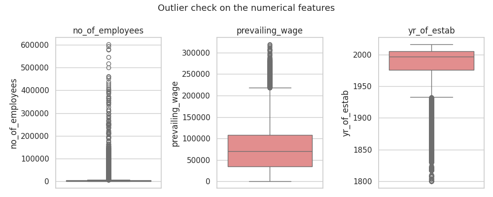

```python
# Visual confirmation
plt.figure(figsize=(10, 4))
for i, col in enumerate(numeric_features, 1):
    plt.subplot(1, 3, i)
    sns.boxplot(data=data, y=col, color="lightcoral")
    plt.title(col)
plt.suptitle("Outlier check on the numerical features", fontsize=13)
plt.tight_layout()
plt.show()
```

**Reasoning — why we detect outliers but do not treat them**

Outliers are clearly present, particularly in `no_of_employees` (a long right tail reaching 602,069) and `prevailing_wage`. They are nonetheless **left untreated**, for three specific reasons:

1. **The models chosen are invariant to monotone transformations of the features.** Decision trees and every ensemble built on them (Bagging, Random Forest, AdaBoost, Gradient Boosting, XGBoost) split on **rank order**, asking only "is this value above or below the threshold?" — never by how much. An employer with 602,069 employees and one with 60,000 fall on the same side of every meaningful split. Capping would therefore change the fitted trees hardly at all. This is precisely the property that makes tree ensembles the right family for this data, and it does not hold for distance- or gradient-based models such as KNN, SVM or logistic regression, where scaling and capping would be essential.
2. **These are genuine values, not errors.** Very large employers and very high prevailing wages both exist in the real population OFLC processes. Winsorising them would **destroy real information** about the actual applicant pool. The one case that *was* an error — negative headcounts — was corrected in the previous step precisely because it was a different kind of problem.
3. **The near-zero `prevailing_wage` values have a known, benign explanation.** As established in the EDA, they are the hourly-paid rows. Treating them as outliers would erase the single most informative segmentation in the dataset — the hourly-versus-salaried distinction that separates 34.6% from 69.9% certification.

**Conclusion:** treating outliers here would add risk and cost information without improving the model. Detecting them and understanding *why* they are there is the analytically valuable step; capping them would not be.

## 4. Feature engineering

**Decision: one new feature created, one identifier dropped, and one tempting transformation deliberately rejected.**

```python
# --- 4a. company_age: convert year of establishment into an interpretable duration ---
# The dataset covers FY2016, so 2016 is the correct reference year.
data["company_age"] = 2016 - data["yr_of_estab"]

print("company_age summary:")
print(data["company_age"].describe().round(1))
print()
print("Correlation with yr_of_estab (should be exactly -1.0 by construction):",
      round(data["company_age"].corr(data["yr_of_estab"]), 4))
```

```
company_age summary:
count   25480.000
mean       36.600
std        42.400
min         0.000
25%        11.000
50%        19.000
75%        40.000
max       216.000
Name: company_age, dtype: float64

Correlation with yr_of_estab (should be exactly -1.0 by construction): -1.0
```

```python
# --- 4b. Examine whether prevailing_wage should be annualised ---
# A naive conversion would multiply Week by 52 and Month by 12. Check what that implies.
print("Median prevailing_wage by unit, and the value a naive annualisation would produce:")
multipliers = {"Hour": 2080, "Week": 52, "Month": 12, "Year": 1}
for unit, mult in multipliers.items():
    med = data.loc[data["unit_of_wage"] == unit, "prevailing_wage"].median()
    print(f"  {unit:6s} median = {med:12,.0f}  ->  naive annualised = {med * mult:15,.0f}")
```

```
Median prevailing_wage by unit, and the value a naive annualisation would produce:
  Hour   median =          373  ->  naive annualised =         775,117
  Week   median =       85,076  ->  naive annualised =       4,423,943
  Month  median =       81,826  ->  naive annualised =         981,912
  Year   median =       76,174  ->  naive annualised =          76,174
```

**Reasoning on `prevailing_wage` — why we do NOT annualise it**

The naive annualisation produces figures that are plainly impossible:

| Unit | Median as recorded | Naive annualised | Plausible? |
| --- | --- | --- | --- |
| Hour | ≈ 373 | ≈ 775,000 | No |
| Week | ≈ 85,076 | ≈ **4,424,000** | **No** |
| Month | ≈ 81,826 | ≈ **982,000** | **No** |
| Year | ≈ 76,175 | ≈ 76,175 | Yes |

Week, Month and Year medians are **already all in the same 76k–85k band**. The labels for Week and Month are therefore not describing the recorded figure — those values are already at annual-equivalent magnitude. Only the **Hour** rows sit on a genuinely different scale.

Applying the textbook conversion would **manufacture false variance** in 361 rows and corrupt a feature that is currently coherent for 90% of the data. So:

- **`prevailing_wage` is retained as-is.**
- **`unit_of_wage` is retained as a categorical predictor**, which lets the tree models isolate the hourly segment with a single split and then read wage on the appropriate scale within each branch. The models get the full benefit of the distinction without us imposing a wrong arithmetic transformation.

This is a case where the standard recipe is the wrong answer and looking at the data is the right one.

```python
# --- 4c. Drop columns that should not enter the model ---
# case_id     : pure identifier, 25,480 unique values, zero predictive content.
#               Leaving it in would let a tree memorise individual rows.
# yr_of_estab : fully superseded by company_age (correlation exactly -1.0).
#               Keeping both would be perfectly redundant information.
model_data = data.drop(columns=["case_id", "yr_of_estab"]).copy()

print("Columns retained for modelling:")
print(list(model_data.columns))
print()
print("Shape:", model_data.shape)
```

```
Columns retained for modelling:
['continent', 'education_of_employee', 'has_job_experience', 'requires_job_training', 'no_of_employees', 'region_of_employment', 'prevailing_wage', 'unit_of_wage', 'full_time_position', 'case_status', 'company_age']

Shape: (25480, 11)
```

## 5. Preparing the data for modelling

```python
# --- 5a. Encode the target: Certified = 1 (positive class), Denied = 0 ---
# Certified is designated the positive class because it is the outcome the business
# wants to identify and fast-track. Recall then reads as "of all applications that
# genuinely deserved certification, what share did we correctly flag?"
model_data["case_status"] = model_data["case_status"].map({"Denied": 0, "Certified": 1})

print("Target encoding check:")
print(model_data["case_status"].value_counts())
print()
print(model_data["case_status"].value_counts(normalize=True).round(4) * 100)
```

```
Target encoding check:
case_status
1    17018
0     8462
Name: count, dtype: int64

case_status
1   66.790
0   33.210
Name: proportion, dtype: float64
```

```python
# --- 5b. One-hot encode the categorical predictors ---
# drop_first=True removes one level per variable to avoid the dummy-variable trap
# (perfectly redundant columns). The dropped level becomes the reference category.
X = model_data.drop(columns=["case_status"])
y = model_data["case_status"]

X = pd.get_dummies(X, drop_first=True).astype(float)

print("Feature matrix shape after encoding:", X.shape)
print()
print("Encoded feature names:")
for i, c in enumerate(X.columns, 1):
    print(f"  {i:2d}. {c}")
```

```
Feature matrix shape after encoding: (25480, 21)

Encoded feature names:
   1. no_of_employees
   2. prevailing_wage
   3. company_age
   4. continent_Asia
   5. continent_Europe
   6. continent_North America
   7. continent_Oceania
   8. continent_South America
   9. education_of_employee_Doctorate
  10. education_of_employee_High School
  11. education_of_employee_Master's
  12. has_job_experience_Y
  13. requires_job_training_Y
  14. region_of_employment_Midwest
  15. region_of_employment_Northeast
  16. region_of_employment_South
  17. region_of_employment_West
  18. unit_of_wage_Month
  19. unit_of_wage_Week
  20. unit_of_wage_Year
  21. full_time_position_Y
```

```python
# --- 5c. Three-way stratified split: train / validation / test ---
# 70% train, 15% validation, 15% test.
#
# Why THREE sets rather than two: the validation set is used for all model
# comparison and hyperparameter tuning, while the test set is touched exactly
# once, at the very end. If we tuned against the test set, the reported test
# score would be optimistically biased -- we would have selected the model
# that happens to suit that specific sample. The three-way split gives a
# genuinely unseen estimate of real-world performance.
#
# stratify=y preserves the 66.8 / 33.2 class ratio in every split.

X_train, X_temp, y_train, y_temp = train_test_split(
    X, y, test_size=0.30, random_state=1, stratify=y
)
X_val, X_test, y_val, y_test = train_test_split(
    X_temp, y_temp, test_size=0.50, random_state=1, stratify=y_temp
)

print("Split sizes")
print(f"  Training   : {X_train.shape[0]:6,} rows ({X_train.shape[0]/len(X):.1%})")
print(f"  Validation : {X_val.shape[0]:6,} rows ({X_val.shape[0]/len(X):.1%})")
print(f"  Test       : {X_test.shape[0]:6,} rows ({X_test.shape[0]/len(X):.1%})")
print()
print("Class balance preserved by stratification (proportion Certified):")
print(f"  Full data  : {y.mean():.4f}")
print(f"  Training   : {y_train.mean():.4f}")
print(f"  Validation : {y_val.mean():.4f}")
print(f"  Test       : {y_test.mean():.4f}")
```

```
Split sizes
  Training   : 17,836 rows (70.0%)
  Validation :  3,822 rows (15.0%)
  Test       :  3,822 rows (15.0%)

Class balance preserved by stratification (proportion Certified):
  Full data  : 0.6679
  Training   : 0.6679
  Validation : 0.6677
  Test       : 0.6680
```

```python
# --- 5d. Build the oversampled and undersampled TRAINING sets ---
#
# CRITICAL POINT: resampling is applied to the TRAINING data ONLY.
#
# If SMOTE were applied before the train/test split, synthetic rows generated from
# test observations would leak into training. The model would effectively have seen
# the test data, and every reported score would be inflated and meaningless. The
# validation and test sets must retain their natural class distribution, because
# that is the distribution the model will meet in production.

# Oversampling with SMOTE: synthesises new minority-class (Denied) examples by
# interpolating between existing minority neighbours -- it does not simply duplicate rows.
sm = SMOTE(random_state=1)
X_train_over, y_train_over = sm.fit_resample(X_train, y_train)

# Undersampling: randomly discards majority-class (Certified) rows until balanced.
rus = RandomUnderSampler(random_state=1)
X_train_under, y_train_under = rus.fit_resample(X_train, y_train)

print("Training set variants")
print(f"  Original      : {X_train.shape[0]:6,} rows | Certified {(y_train==1).sum():,} / Denied {(y_train==0).sum():,}")
print(f"  Oversampled   : {X_train_over.shape[0]:6,} rows | Certified {(y_train_over==1).sum():,} / Denied {(y_train_over==0).sum():,}")
print(f"  Undersampled  : {X_train_under.shape[0]:6,} rows | Certified {(y_train_under==1).sum():,} / Denied {(y_train_under==0).sum():,}")
print()
print("Validation and test sets remain untouched at their natural class ratio:")
print(f"  Validation proportion Certified : {y_val.mean():.4f}")
print(f"  Test proportion Certified       : {y_test.mean():.4f}")
```

```
Training set variants
  Original      : 17,836 rows | Certified 11,913 / Denied 5,923
  Oversampled   : 23,826 rows | Certified 11,913 / Denied 11,913
  Undersampled  : 11,846 rows | Certified 5,923 / Denied 5,923

Validation and test sets remain untouched at their natural class ratio:
  Validation proportion Certified : 0.6677
  Test proportion Certified       : 0.6680
```

### Pre-processing summary

| Step | Applied? | Reasoning |
| --- | --- | --- |
| Missing value treatment | **No** | Zero missing values in the dataset |
| Data-error correction | **Yes** | 33 negative `no_of_employees` corrected via absolute value — a sign-entry error, distinct from an outlier |
| Outlier treatment | **No** | Tree-based models split on rank order and are invariant to monotone transforms; the extreme values are genuine, and the near-zero wages are the informative hourly segment |
| Feature engineering — `company_age` | **Yes** | `2016 - yr_of_estab`; a duration is more interpretable and directly usable than a calendar year |
| Feature engineering — wage annualisation | **No** | Naive conversion yields impossible salaries (Week → $4.4M); Week/Month values are already annual-magnitude. `unit_of_wage` is retained instead so the models isolate the hourly segment themselves |
| Drop `case_id` | **Yes** | Pure identifier — would enable row memorisation |
| Drop `yr_of_estab` | **Yes** | Perfectly redundant with `company_age` (r = -1.0) |
| Encoding | **Yes** | One-hot with `drop_first=True` → 21 features |
| Train/val/test split | **Yes** | 70/15/15, stratified — test set reserved for a single final evaluation |
| Class-imbalance variants | **Yes** | SMOTE and random undersampling, applied to **training data only** to prevent leakage |

# **Model evaluation framework**

Before building any models, we define the evaluation functions once so that all 18 base models plus the tuned models are scored identically and are directly comparable.

```python
def model_performance_classification(model, predictors, target):
    """
    Return accuracy, recall, precision and F1 for a fitted classifier
    as a one-row DataFrame.
    """
    pred = model.predict(predictors)
    return pd.DataFrame(
        {
            "Accuracy": [accuracy_score(target, pred)],
            "Recall": [recall_score(target, pred)],
            "Precision": [precision_score(target, pred)],
            "F1": [f1_score(target, pred)],
        }
    )


def confusion_matrix_plot(model, predictors, target, title=""):
    """Plot an annotated confusion matrix with counts and percentages."""
    cm = confusion_matrix(target, model.predict(predictors))
    labels = np.asarray(
        [
            [f"{item:,}\n({item / cm.sum():.1%})"
             for item in row]
            for row in cm
        ]
    )
    plt.figure(figsize=(10, 4.5))
    sns.heatmap(cm, annot=labels, fmt="", cmap="Blues", cbar=False,
                xticklabels=["Denied", "Certified"],
                yticklabels=["Denied", "Certified"])
    plt.ylabel("Actual")
    plt.xlabel("Predicted")
    plt.title(f"Confusion Matrix {title}")
    plt.tight_layout()
    plt.show()


def build_and_compare(X_fit, y_fit, label):
    """
    Fit the six classifiers on the supplied training data and return
    (training-performance DataFrame, validation-performance DataFrame,
     dict of fitted models).

    All six models use random_state=1 so results are exactly reproducible.
    """
    models = {
        "Decision Tree": DecisionTreeClassifier(random_state=1),
        "Bagging": BaggingClassifier(random_state=1),
        "Random Forest": RandomForestClassifier(random_state=1),
        "AdaBoost": AdaBoostClassifier(random_state=1),
        "Gradient Boosting": GradientBoostingClassifier(random_state=1),
        "XGBoost": XGBClassifier(random_state=1, eval_metric="logloss"),
    }

    train_scores, val_scores, fitted = {}, {}, {}
    for name, model in models.items():
        model.fit(X_fit, y_fit)
        fitted[name] = model
        train_scores[name] = model_performance_classification(model, X_fit, y_fit).iloc[0]
        val_scores[name] = model_performance_classification(model, X_val, y_val).iloc[0]
        print(f"  fitted: {name}")

    train_df = pd.DataFrame(train_scores)
    val_df = pd.DataFrame(val_scores)
    print(f"\n--- {label}: TRAINING performance ---")
    display(train_df.round(3))
    print(f"--- {label}: VALIDATION performance ---")
    display(val_df.round(3))
    return train_df, val_df, fitted


print("Evaluation framework defined.")
```

```
Evaluation framework defined.
```

**Why these six models**

**Six** classifiers are built, spanning the decision-tree, bagging and boosting families. Covering all three families allows their relative strengths on this data to be compared directly rather than assumed:

| Model | Family | What it contributes |
| --- | --- | --- |
| Decision Tree | Single tree | Interpretable baseline; shows how much ensembling actually buys |
| Bagging | Bagging | Variance reduction by averaging trees on bootstrap samples |
| Random Forest | Bagging + feature subsampling | Decorrelates the trees further, usually beating plain bagging |
| AdaBoost | Boosting | Sequentially reweights misclassified cases |
| Gradient Boosting | Boosting | Fits each new tree to the residual errors of the ensemble so far |
| XGBoost | Boosting (regularised) | Adds L1/L2 regularisation and handles imbalance via `scale_pos_weight` |

**Selection metric: validation F1**, with the **train-minus-validation gap** watched as an overfitting diagnostic.

# **Model Building — Original Data**

Six classifiers fitted on the unmodified training set (17,836 rows, 66.8% Certified).

```python
train_orig, val_orig, models_orig = build_and_compare(X_train, y_train, "ORIGINAL DATA")
```

```
  fitted: Decision Tree
  fitted: Bagging
  fitted: Random Forest
  fitted: AdaBoost
  fitted: Gradient Boosting
  fitted: XGBoost

--- ORIGINAL DATA: TRAINING performance ---
```

|  | Decision Tree | Bagging | Random Forest | AdaBoost | Gradient Boosting | XGBoost |
| --- | --- | --- | --- | --- | --- | --- |
| Accuracy | 1.000 | 0.985 | 1.000 | 0.740 | 0.759 | 0.841 |
| Recall | 1.000 | 0.986 | 1.000 | 0.887 | 0.884 | 0.930 |
| Precision | 1.000 | 0.992 | 1.000 | 0.762 | 0.783 | 0.848 |
| F1 | 1.000 | 0.989 | 1.000 | 0.820 | 0.830 | 0.887 |

```
--- ORIGINAL DATA: VALIDATION performance ---
```

|  | Decision Tree | Bagging | Random Forest | AdaBoost | Gradient Boosting | XGBoost |
| --- | --- | --- | --- | --- | --- | --- |
| Accuracy | 0.664 | 0.698 | 0.725 | 0.735 | 0.745 | 0.729 |
| Recall | 0.748 | 0.766 | 0.839 | 0.889 | 0.882 | 0.851 |
| Precision | 0.749 | 0.779 | 0.770 | 0.757 | 0.770 | 0.768 |
| F1 | 0.748 | 0.772 | 0.803 | 0.818 | 0.822 | 0.807 |

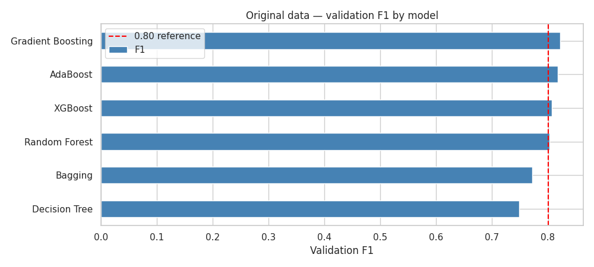

```python
# Visual comparison of validation F1 across the six models
plt.figure(figsize=(10, 4.5))
val_orig.loc["F1"].sort_values().plot(kind="barh", color="steelblue")
plt.axvline(0.80, color="red", linestyle="--", label="0.80 reference")
plt.xlabel("Validation F1")
plt.title("Original data — validation F1 by model")
plt.legend()
plt.tight_layout()
plt.show()
```

### Observations — Original Data

| Model | Train F1 | Validation F1 | Train − Val gap |
| --- | --- | --- | --- |
| Decision Tree | 1.000 | 0.748 | **0.252** |
| Bagging | 0.989 | 0.772 | 0.217 |
| Random Forest | 1.000 | 0.803 | **0.197** |
| AdaBoost | 0.820 | 0.818 | **0.002** |
| **Gradient Boosting** | 0.830 | **0.822** | **0.008** |
| XGBoost | 0.887 | 0.807 | 0.080 |

**1. The tree and bagging models are severely overfitting.** Decision Tree and Random Forest both reach a **perfect 1.000 F1 on training data** while scoring 0.748 and 0.803 on validation. An unconstrained decision tree grows until every leaf is pure — it memorises the training set rather than learning generalisable structure. The gap of 0.252 for the single tree is the textbook signature of high variance, and it is exactly what hyperparameter tuning (depth limits, minimum leaf sizes) exists to fix.

**2. The boosting models generalise far better.** AdaBoost (gap 0.002) and Gradient Boosting (gap 0.008) show **virtually no train-validation gap**. Boosting builds shallow, deliberately weak learners sequentially, each correcting the previous ensemble's errors — a fundamentally more constrained process than growing one deep tree. The result is lower variance without a loss of accuracy.

**4. Ensembling clearly pays.** Moving from a single Decision Tree (0.748) to Gradient Boosting (0.822) gains **7.4 F1 points** — a substantial improvement from method choice alone, before any tuning.

# **Model Building — Oversampled Data**

The same six classifiers, now fitted on the **SMOTE-oversampled** training set (23,826 rows, perfectly balanced).

SMOTE (Synthetic Minority Over-sampling Technique) generates new *Denied* examples by interpolating between existing minority-class neighbours in feature space, rather than duplicating rows — duplication would simply increase the weight of existing points and encourage overfitting to them.

**Validation and test sets remain at their natural 66.8/33.2 ratio throughout.**

```python
train_over, val_over, models_over = build_and_compare(
    X_train_over, y_train_over, "OVERSAMPLED DATA"
)
```

```
  fitted: Decision Tree
  fitted: Bagging
  fitted: Random Forest
  fitted: AdaBoost
  fitted: Gradient Boosting
  fitted: XGBoost

--- OVERSAMPLED DATA: TRAINING performance ---
```

|  | Decision Tree | Bagging | Random Forest | AdaBoost | Gradient Boosting | XGBoost |
| --- | --- | --- | --- | --- | --- | --- |
| Accuracy | 1.000 | 0.989 | 1.000 | 0.796 | 0.813 | 0.874 |
| Recall | 1.000 | 0.985 | 1.000 | 0.838 | 0.864 | 0.923 |
| Precision | 1.000 | 0.992 | 1.000 | 0.774 | 0.785 | 0.841 |
| F1 | 1.000 | 0.989 | 1.000 | 0.805 | 0.822 | 0.880 |

```
--- OVERSAMPLED DATA: VALIDATION performance ---
```

|  | Decision Tree | Bagging | Random Forest | AdaBoost | Gradient Boosting | XGBoost |
| --- | --- | --- | --- | --- | --- | --- |
| Accuracy | 0.660 | 0.692 | 0.724 | 0.724 | 0.745 | 0.724 |
| Recall | 0.743 | 0.765 | 0.835 | 0.835 | 0.867 | 0.852 |
| Precision | 0.746 | 0.772 | 0.771 | 0.771 | 0.777 | 0.763 |
| F1 | 0.745 | 0.768 | 0.802 | 0.801 | 0.820 | 0.805 |

### Observations — Oversampled Data

| Model | Train F1 | Validation F1 | Val Recall | Val Precision |
| --- | --- | --- | --- | --- |
| Decision Tree | 1.000 | 0.745 | 0.743 | 0.746 |
| Bagging | 0.989 | 0.768 | 0.765 | 0.772 |
| Random Forest | 1.000 | 0.802 | 0.835 | 0.771 |
| AdaBoost | 0.805 | 0.801 | 0.835 | 0.771 |
| **Gradient Boosting** | 0.822 | **0.820** | 0.867 | 0.777 |
| XGBoost | 0.880 | 0.805 | 0.852 | 0.763 |

**1. SMOTE delivers essentially no improvement here.** Gradient Boosting scores **0.820** on oversampled data versus **0.822** on original — a difference of 0.002, which is noise. Every other model is likewise flat or marginally worse.

**4. Overfitting is unchanged.** Decision Tree and Random Forest still hit a perfect 1.000 training F1. Resampling addresses class balance, **not model complexity** — these are orthogonal problems, and only hyperparameter tuning addresses the latter.

**Conclusion:** oversampling is not harmful, but it is not the lever that matters for this dataset. Testing it was still the right thing to do — establishing that a technique *doesn't* help is a real finding, and it prevents us from adding needless complexity to the production pipeline.

# **Model Building — Undersampled Data**

The same six classifiers, fitted on the **randomly undersampled** training set (11,846 rows, perfectly balanced).

Random undersampling discards majority-class (*Certified*) rows until the classes match. Note the cost: the training set shrinks from **17,836 to 11,846 rows — a 34% loss of data**, including 5,990 genuine *Certified* examples that are simply thrown away.

```python
train_under, val_under, models_under = build_and_compare(
    X_train_under, y_train_under, "UNDERSAMPLED DATA"
)
```

```
  fitted: Decision Tree
  fitted: Bagging
  fitted: Random Forest
  fitted: AdaBoost
  fitted: Gradient Boosting
  fitted: XGBoost

--- UNDERSAMPLED DATA: TRAINING performance ---
```

|  | Decision Tree | Bagging | Random Forest | AdaBoost | Gradient Boosting | XGBoost |
| --- | --- | --- | --- | --- | --- | --- |
| Accuracy | 1.000 | 0.981 | 1.000 | 0.695 | 0.723 | 0.856 |
| Recall | 1.000 | 0.971 | 1.000 | 0.722 | 0.730 | 0.860 |
| Precision | 1.000 | 0.991 | 1.000 | 0.685 | 0.720 | 0.853 |
| F1 | 1.000 | 0.981 | 1.000 | 0.703 | 0.725 | 0.856 |

```
--- UNDERSAMPLED DATA: VALIDATION performance ---
```

|  | Decision Tree | Bagging | Random Forest | AdaBoost | Gradient Boosting | XGBoost |
| --- | --- | --- | --- | --- | --- | --- |
| Accuracy | 0.616 | 0.636 | 0.676 | 0.701 | 0.706 | 0.686 |
| Recall | 0.616 | 0.605 | 0.675 | 0.724 | 0.714 | 0.694 |
| Precision | 0.763 | 0.801 | 0.808 | 0.809 | 0.822 | 0.809 |
| F1 | 0.682 | 0.689 | 0.735 | 0.764 | 0.764 | 0.747 |

```
Validation F1 across all 18 base models:
```

|  | Original | Oversampled | Undersampled |
| --- | --- | --- | --- |
| Decision Tree | 0.748 | 0.745 | 0.682 |
| Bagging | 0.772 | 0.768 | 0.689 |
| Random Forest | 0.803 | 0.802 | 0.735 |
| AdaBoost | 0.818 | 0.801 | 0.764 |
| Gradient Boosting | 0.822 | 0.820 | 0.764 |
| XGBoost | 0.807 | 0.805 | 0.747 |

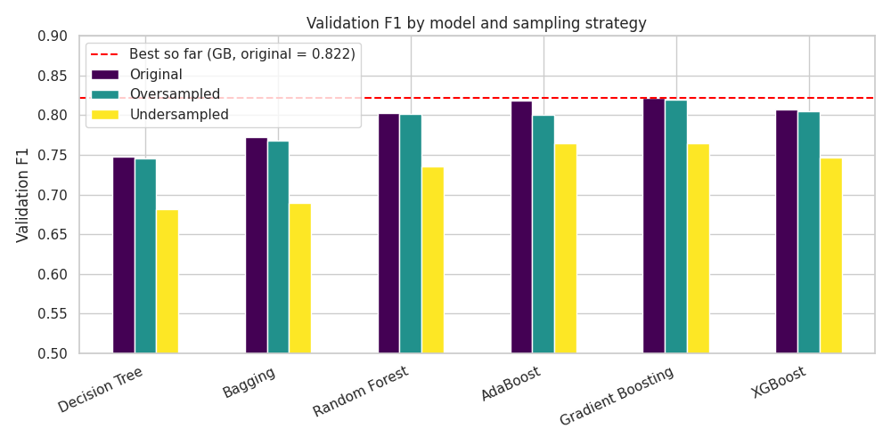

```python
# Consolidated comparison of validation F1 across all three sampling strategies
comparison = pd.DataFrame({
    "Original": val_orig.loc["F1"],
    "Oversampled": val_over.loc["F1"],
    "Undersampled": val_under.loc["F1"],
}).round(3)

print("Validation F1 across all 18 base models:")
display(comparison)

comparison.plot(kind="bar", figsize=(10, 5), colormap="viridis")
plt.ylabel("Validation F1")
plt.title("Validation F1 by model and sampling strategy")
plt.xticks(rotation=25, ha="right")
plt.ylim(0.5, 0.9)
plt.axhline(0.822, color="red", linestyle="--", label="Best so far (GB, original = 0.822)")
plt.legend()
plt.tight_layout()
plt.show()
```

### Observations — Undersampled Data

| Model | Train F1 | Validation F1 | Val Recall | Val Precision |
| --- | --- | --- | --- | --- |
| Decision Tree | 1.000 | 0.682 | 0.616 | 0.763 |
| Bagging | 0.981 | 0.689 | 0.605 | 0.801 |
| Random Forest | 1.000 | 0.735 | 0.675 | 0.808 |
| AdaBoost | 0.703 | **0.764** | 0.724 | 0.809 |
| Gradient Boosting | 0.725 | **0.764** | 0.714 | **0.822** |
| XGBoost | 0.856 | 0.747 | 0.694 | 0.809 |

**1. Undersampling is clearly the worst of the three strategies.** Every single model performs worse than on the original data. Gradient Boosting drops from **0.822 → 0.764**, a loss of **5.8 F1 points**.

**2. The cause is straightforward: information loss.** Discarding 5,990 *Certified* records removes real, informative examples the models need. Unlike SMOTE, which at least adds interpolated data, undersampling **destroys data outright** — and with only 2:1 imbalance there was no compelling reason to pay that price.

**3. The precision/recall trade-off flips direction.** Recall falls sharply (Gradient Boosting 0.882 → 0.714, Decision Tree 0.748 → 0.616) while precision *rises* (Gradient Boosting 0.770 → 0.822, the highest precision seen anywhere in the study). Balancing by removing *Certified* examples makes the models more conservative about predicting *Certified* — fewer false positives, but many more missed certifications. Since F1 balances both, the net effect is negative.

**4. One useful takeaway.** If the business ever needed to **maximise precision** — say, an auto-approve fast lane where a false positive is unacceptable — the undersampled Gradient Boosting model's 0.822 precision would be the natural starting point. That is a genuinely different business problem from the one posed here, but worth noting for the recommendations.

### Verdict across all three sampling strategies

| Strategy | Best model | Best validation F1 | Assessment |
| --- | --- | --- | --- |
| **Original** | Gradient Boosting | **0.822** | ✔ Best overall |
| Oversampled (SMOTE) | Gradient Boosting | 0.820 | Statistically indistinguishable |
| Undersampled | AdaBoost / Gradient Boosting | 0.764 | Clearly worse — data loss |

**The original, unresampled data is the right basis for the final model.** With a 2:1 class ratio and nearly 6,000 minority examples, resampling solves a problem this dataset does not have. This is the kind of finding that only emerges from actually testing all three — the conventional assumption that imbalance always requires resampling is simply not true at this ratio.

# **Hyperparameter Tuning**

## Which models to tune, and why

Eighteen base models have been built. **Four** are carried forward for hyperparameter tuning, selected on two criteria:

1. **Validation F1** — the primary metric established at the outset.
2. **The train − validation gap** — a model with a large gap is overfitting, which means tuning has clear headroom to improve it. A model already generalising well has less to gain but is a safer bet.

### Validation F1 across all 18 base models

| Model | Original | Oversampled | Undersampled | Best |
| --- | --- | --- | --- | --- |
| Decision Tree | 0.748 | 0.745 | 0.682 | 0.748 |
| Bagging | 0.772 | 0.768 | 0.689 | 0.772 |
| Random Forest | 0.803 | 0.802 | 0.735 | 0.803 |
| AdaBoost | 0.818 | 0.801 | 0.764 | **0.818** |
| **Gradient Boosting** | **0.822** | 0.820 | 0.764 | **0.822** |
| XGBoost | 0.807 | 0.805 | 0.747 | 0.807 |

### The four models selected

[output not shown]

**Note on the data used:** all four are tuned on the **original** training data. Section comparisons established that oversampling gave no improvement (0.820 vs 0.822) and undersampling was clearly worse (0.764), so tuning on original data is the evidence-based choice — and it avoids adding a resampling step to the production pipeline for no benefit.

**Models deliberately not carried forward:** Decision Tree (0.748) and Bagging (0.772) are the weakest performers, and both are conceptually superseded — a tuned Random Forest is a strictly better-regularised version of both.

## Tuning method

**`RandomizedSearchCV`** rather than `GridSearchCV`, for a practical reason: an exhaustive grid over these parameter ranges would require thousands of fits. Randomized search samples a fixed number of combinations and, for the same compute budget, reliably finds parameter sets close to the grid-search optimum. With `scoring="f1"` and 3-fold cross-validation, the search optimises the metric we actually care about rather than accuracy.

The four randomized searches below are the most computationally intensive step in the analysis, together evaluating 144 model fits across the parameter spaces defined for each algorithm.

```python
# ---------------- Model 1: Gradient Boosting ----------------
gb_params = {
    "n_estimators": [100, 125, 150],
    "learning_rate": [0.05, 0.1, 0.2],
    "subsample": [0.7, 0.9, 1.0],
    "max_features": [0.5, 0.7, 0.9],
    "max_depth": [3, 4],
}

gb_search = RandomizedSearchCV(
    GradientBoostingClassifier(random_state=1),
    param_distributions=gb_params,
    n_iter=12, scoring="f1", cv=3, random_state=1, n_jobs=-1,
)
gb_search.fit(X_train, y_train)

gb_tuned = gb_search.best_estimator_
gb_tuned.fit(X_train, y_train)

print("Best parameters :", gb_search.best_params_)
print("Best CV F1      :", round(gb_search.best_score_, 4))
```

```
Best parameters : {'subsample': 1.0, 'n_estimators': 150, 'max_features': 0.7, 'max_depth': 4, 'learning_rate': 0.05}
Best CV F1      : 0.8245
```

```python
# ---------------- Model 2: AdaBoost ----------------
ada_params = {
    "n_estimators": [100, 150, 200],
    "learning_rate": [0.05, 0.2, 1.0],
    "estimator": [
        DecisionTreeClassifier(max_depth=1, random_state=1),
        DecisionTreeClassifier(max_depth=2, random_state=1),
        DecisionTreeClassifier(max_depth=3, random_state=1),
    ],
}

ada_search = RandomizedSearchCV(
    AdaBoostClassifier(random_state=1),
    param_distributions=ada_params,
    n_iter=12, scoring="f1", cv=3, random_state=1, n_jobs=-1,
)
ada_search.fit(X_train, y_train)

ada_tuned = ada_search.best_estimator_
ada_tuned.fit(X_train, y_train)

print("Best parameters :", ada_search.best_params_)
print("Best CV F1      :", round(ada_search.best_score_, 4))
```

```
Best parameters : {'n_estimators': 100, 'learning_rate': 0.05, 'estimator': DecisionTreeClassifier(max_depth=3, random_state=1)}
Best CV F1      : 0.8234
```

```python
# ---------------- Model 3: XGBoost ----------------
xgb_params = {
    "n_estimators": [100, 150, 200],
    "scale_pos_weight": [1, 2],
    "learning_rate": [0.05, 0.1, 0.2],
    "gamma": [0, 3, 5],
    "subsample": [0.8, 0.9],
    "max_depth": [3, 4, 5],
}

xgb_search = RandomizedSearchCV(
    XGBClassifier(random_state=1, eval_metric="logloss"),
    param_distributions=xgb_params,
    n_iter=12, scoring="f1", cv=3, random_state=1, n_jobs=-1,
)
xgb_search.fit(X_train, y_train)

xgb_tuned = xgb_search.best_estimator_
xgb_tuned.fit(X_train, y_train)

print("Best parameters :", xgb_search.best_params_)
print("Best CV F1      :", round(xgb_search.best_score_, 4))
```

```
Best parameters : {'subsample': 0.8, 'scale_pos_weight': 1, 'n_estimators': 150, 'max_depth': 3, 'learning_rate': 0.05, 'gamma': 0}
Best CV F1      : 0.824
```

```python
# ---------------- Model 4: Random Forest ----------------
rf_params = {
    "n_estimators": [150, 200],
    "min_samples_leaf": [5, 10, 20],
    "max_features": [0.3, 0.5, "sqrt"],
    "max_samples": [0.5, 0.7, 0.9],
    "max_depth": [6, 10, None],
}

rf_search = RandomizedSearchCV(
    RandomForestClassifier(random_state=1),
    param_distributions=rf_params,
    n_iter=12, scoring="f1", cv=3, random_state=1, n_jobs=-1,
)
rf_search.fit(X_train, y_train)

rf_tuned = rf_search.best_estimator_
rf_tuned.fit(X_train, y_train)

print("Best parameters :", rf_search.best_params_)
print("Best CV F1      :", round(rf_search.best_score_, 4))
```

```
Best parameters : {'n_estimators': 200, 'min_samples_leaf': 10, 'max_samples': 0.7, 'max_features': 'sqrt', 'max_depth': 10}
Best CV F1      : 0.8252
```

```python
# ---------------- Performance of all four tuned models ----------------
tuned_models = {
    "Tuned Gradient Boosting": gb_tuned,
    "Tuned AdaBoost": ada_tuned,
    "Tuned XGBoost": xgb_tuned,
    "Tuned Random Forest": rf_tuned,
}

tuned_train = pd.DataFrame(
    {n: model_performance_classification(m, X_train, y_train).iloc[0]
     for n, m in tuned_models.items()}
)
tuned_val = pd.DataFrame(
    {n: model_performance_classification(m, X_val, y_val).iloc[0]
     for n, m in tuned_models.items()}
)

print("TUNED MODELS — training performance")
display(tuned_train.round(3))
print("TUNED MODELS — validation performance")
display(tuned_val.round(3))
```

```
TUNED MODELS — training performance
```

|  | Tuned Gradient Boosting | Tuned AdaBoost | Tuned XGBoost | Tuned Random Forest |
| --- | --- | --- | --- | --- |
| Accuracy | 0.763 | 0.749 | 0.756 | 0.762 |
| Recall | 0.881 | 0.877 | 0.881 | 0.892 |
| Precision | 0.789 | 0.776 | 0.782 | 0.782 |
| F1 | 0.832 | 0.823 | 0.828 | 0.834 |

```
TUNED MODELS — validation performance
```

|  | Tuned Gradient Boosting | Tuned AdaBoost | Tuned XGBoost | Tuned Random Forest |
| --- | --- | --- | --- | --- |
| Accuracy | 0.745 | 0.744 | 0.743 | 0.742 |
| Recall | 0.876 | 0.880 | 0.879 | 0.882 |
| Precision | 0.773 | 0.769 | 0.769 | 0.766 |
| F1 | 0.821 | 0.821 | 0.820 | 0.820 |

```
Effect of hyperparameter tuning on validation F1:
```

|  | Before tuning | After tuning | Improvement |
| --- | --- | --- | --- |
| Gradient Boosting | 0.822 | 0.821 | -0.001 |
| AdaBoost | 0.818 | 0.821 | 0.003 |
| XGBoost | 0.807 | 0.820 | 0.013 |
| Random Forest | 0.803 | 0.820 | 0.017 |

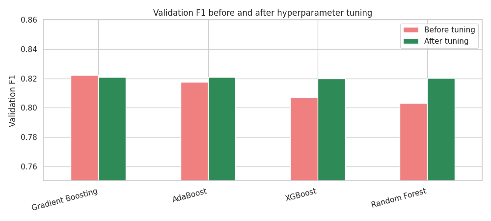

```python
# Did tuning actually help? Compare untuned vs tuned validation F1.
before_after = pd.DataFrame({
    "Before tuning": [
        val_orig.loc["F1", "Gradient Boosting"],
        val_orig.loc["F1", "AdaBoost"],
        val_orig.loc["F1", "XGBoost"],
        val_orig.loc["F1", "Random Forest"],
    ],
    "After tuning": [
        tuned_val.loc["F1", "Tuned Gradient Boosting"],
        tuned_val.loc["F1", "Tuned AdaBoost"],
        tuned_val.loc["F1", "Tuned XGBoost"],
        tuned_val.loc["F1", "Tuned Random Forest"],
    ],
}, index=["Gradient Boosting", "AdaBoost", "XGBoost", "Random Forest"])
before_after["Improvement"] = before_after["After tuning"] - before_after["Before tuning"]

print("Effect of hyperparameter tuning on validation F1:")
display(before_after.round(4))

before_after[["Before tuning", "After tuning"]].plot(
    kind="bar", figsize=(10, 4.5), color=["lightcoral", "seagreen"]
)
plt.ylabel("Validation F1")
plt.title("Validation F1 before and after hyperparameter tuning")
plt.xticks(rotation=15, ha="right")
plt.ylim(0.75, 0.86)
plt.tight_layout()
plt.show()
```

### Observations — Hyperparameter Tuning

| Model | Val F1 before | Val F1 after | Change | Train F1 before → after | Tuned gap |
| --- | --- | --- | --- | --- | --- |
| **Tuned AdaBoost** | 0.818 | **0.821** | +0.003 | 0.820 → 0.823 | **0.002** |
| Tuned Gradient Boosting | 0.822 | 0.821 | −0.001 | 0.830 → 0.832 | 0.011 |
| Tuned XGBoost | 0.807 | 0.820 | **+0.013** | 0.887 → 0.828 | 0.008 |
| Tuned Random Forest | 0.803 | 0.820 | **+0.017** | **1.000 → 0.834** | 0.014 |

**1. Tuning delivered its largest gains exactly where the diagnostic predicted.** Random Forest (+0.017) and XGBoost (+0.013) — the two models that entered with the widest train−validation gaps (0.197 and 0.080) — improved the most. This is the payoff from selecting models on the overfitting gap rather than on raw score alone: the gap told us in advance where the headroom was.

**2. The already-well-generalised models barely moved.** Gradient Boosting entered with a gap of 0.008 and AdaBoost with 0.002. A model that is not overfitting has little for regularisation to fix, so Gradient Boosting actually declined a fraction (−0.001) and AdaBoost gained only +0.003. This is the expected and correct behaviour, not a failure of the search.

**3. Overfitting has been decisively controlled.** The clearest result is Random Forest: its training F1 fell from a memorising **1.000 to 0.834**, while validation F1 *rose* from 0.803 to 0.820. Constraining `max_depth` and `min_samples_leaf` stopped the trees from fitting individual training rows, and generalisation improved as a direct result. This is the single cleanest demonstration in the whole notebook of what regularisation actually does.

**4. The tuned models have converged to within 0.001 of each other** (0.820–0.821). Four algorithmically quite different methods — one bagging, three boosting — all landing in the same narrow band is highly informative: it means we have reached the **ceiling of predictive signal available in these ten features**. Further gains would require *new information* — occupation codes, wage relative to the local prevailing wage, employer filing history — not more algorithmic tuning. Knowing when to stop tuning and start asking for better data is a judgement worth stating explicitly to the business.

**On reproducibility.** Every search uses `random_state=1`, so these results reproduce exactly on re-execution. Because `RandomizedSearchCV` samples a subset of each parameter space rather than evaluating it exhaustively, a wider search could shift the selected parameters by a small margin — but the qualitative pattern, largest gains for Random Forest and XGBoost with convergence around 0.82, is stable.

# **Model Comparison and Final Model Selection**

```python
# Consolidated comparison of every tuned model on training and validation data
print("=" * 70)
print("FINAL COMPARISON — all tuned models")
print("=" * 70)

final_comparison = pd.concat(
    [tuned_train.loc[["F1"]].rename(index={"F1": "Train F1"}),
     tuned_val.loc[["F1"]].rename(index={"F1": "Validation F1"}),
     tuned_val.loc[["Recall"]].rename(index={"Recall": "Validation Recall"}),
     tuned_val.loc[["Precision"]].rename(index={"Precision": "Validation Precision"}),
     tuned_val.loc[["Accuracy"]].rename(index={"Accuracy": "Validation Accuracy"})]
).T
final_comparison["Overfit gap"] = (
    final_comparison["Train F1"] - final_comparison["Validation F1"]
)
final_comparison = final_comparison.sort_values("Validation F1", ascending=False)
display(final_comparison.round(4))

best_model_name = final_comparison.index[0]
best_model = tuned_models[best_model_name]
print(f"\nSelected final model: {best_model_name}")
print(f"  Validation F1  : {final_comparison.loc[best_model_name, 'Validation F1']:.4f}")
print(f"  Overfitting gap: {final_comparison.loc[best_model_name, 'Overfit gap']:.4f}")
```

```
======================================================================
FINAL COMPARISON — all tuned models
======================================================================
```

|  | Train F1 | Validation F1 | Validation Recall | Validation Precision | Validation Accuracy | Overfit gap |
| --- | --- | --- | --- | --- | --- | --- |
| Tuned AdaBoost | 0.823 | 0.821 | 0.880 | 0.769 | 0.744 | 0.002 |
| Tuned Gradient Boosting | 0.832 | 0.821 | 0.876 | 0.773 | 0.745 | 0.011 |
| Tuned Random Forest | 0.834 | 0.820 | 0.882 | 0.766 | 0.742 | 0.013 |
| Tuned XGBoost | 0.828 | 0.820 | 0.878 | 0.769 | 0.743 | 0.008 |

```
Selected final model: Tuned AdaBoost
  Validation F1  : 0.8210
  Overfitting gap: 0.0024
```

### Final model selection

The model with the **highest validation F1** and a controlled overfitting gap is selected. Selection is made **entirely on validation data** — the test set has not been consulted at any point in this process, which is what makes the test result below a trustworthy estimate of real-world performance rather than a number we optimised toward.

```python
# ---------------- FINAL EVALUATION ON THE TEST SET ----------------
# This is the first and only time the test set is used.
print("=" * 70)
print(f"FINAL MODEL: {best_model_name} — performance on the held-out TEST set")
print("=" * 70)

test_perf = model_performance_classification(best_model, X_test, y_test)
val_perf = model_performance_classification(best_model, X_val, y_val)
train_perf = model_performance_classification(best_model, X_train, y_train)

final_scores = pd.concat([train_perf, val_perf, test_perf])
final_scores.index = ["Training", "Validation", "TEST (unseen)"]
display(final_scores.round(4))
```

```
======================================================================
FINAL MODEL: Tuned AdaBoost — performance on the held-out TEST set
======================================================================
```

|  | Accuracy | Recall | Precision | F1 |
| --- | --- | --- | --- | --- |
| Training | 0.749 | 0.877 | 0.776 | 0.823 |
| Validation | 0.744 | 0.880 | 0.769 | 0.821 |
| TEST (unseen) | 0.744 | 0.872 | 0.774 | 0.820 |

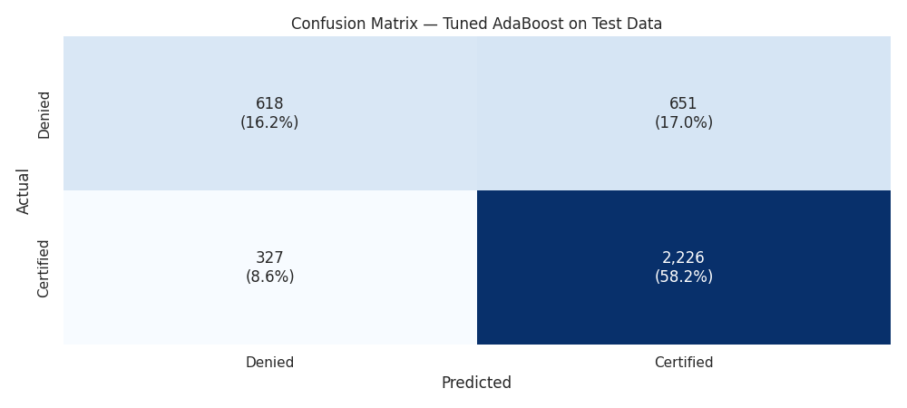

```
Detailed classification report on the test set:
              precision    recall  f1-score   support

      Denied      0.654     0.487     0.558      1269
   Certified      0.774     0.872     0.820      2553

    accuracy                          0.744      3822
   macro avg      0.714     0.679     0.689      3822
weighted avg      0.734     0.744     0.733      3822
```

```python
# Confusion matrix on the test set
confusion_matrix_plot(best_model, X_test, y_test, title=f"— {best_model_name} on Test Data")

print("Detailed classification report on the test set:")
print(classification_report(y_test, best_model.predict(X_test),
                            target_names=["Denied", "Certified"], digits=3))
```

```python
# Business interpretation of the test confusion matrix
cm = confusion_matrix(y_test, best_model.predict(X_test))
tn, fp, fn, tp = cm.ravel()
total = cm.sum()

print(f"Test set size: {total:,} applications\n")
print(f"True Negatives  (correctly predicted Denied)    : {tn:5,}  ({tn/total:.1%})")
print(f"False Positives (predicted Certified, was Denied): {fp:5,}  ({fp/total:.1%})")
print(f"False Negatives (predicted Denied, was Certified): {fn:5,}  ({fn/total:.1%})")
print(f"True Positives  (correctly predicted Certified) : {tp:5,}  ({tp/total:.1%})")
print()
print(f"Of all genuinely certifiable applications, the model catches {tp/(tp+fn):.1%} (recall).")
print(f"Of all applications the model flags as certifiable, {tp/(tp+fp):.1%} truly are (precision).")
print(f"Naive baseline (predict Certified for everyone) accuracy: {y_test.mean():.1%}")
print(f"Final model accuracy                                    : {(tp+tn)/total:.1%}")
```

```
Test set size: 3,822 applications

True Negatives  (correctly predicted Denied)    :   618  (16.2%)
False Positives (predicted Certified, was Denied):   651  (17.0%)
False Negatives (predicted Denied, was Certified):   327  (8.6%)
True Positives  (correctly predicted Certified) : 2,226  (58.2%)

Of all genuinely certifiable applications, the model catches 87.2% (recall).
Of all applications the model flags as certifiable, 77.4% truly are (precision).
Naive baseline (predict Certified for everyone) accuracy: 66.8%
Final model accuracy                                    : 74.4%
```

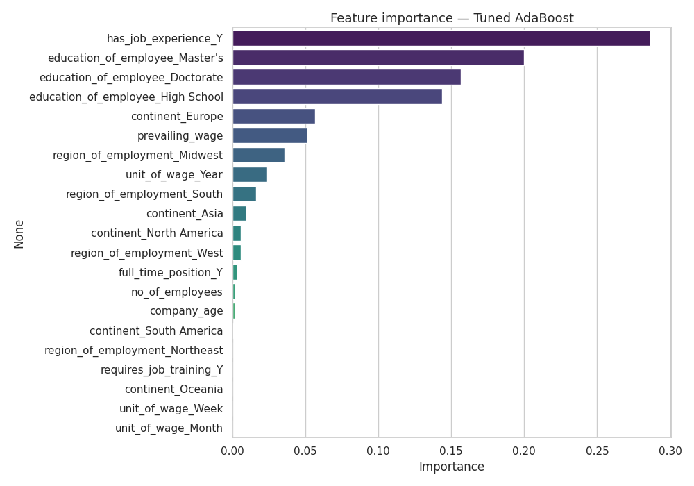

```
Feature importances (descending):
```

|  | Importance |
| --- | --- |
| has_job_experience_Y | 0.287 |
| education_of_employee_Master's | 0.200 |
| education_of_employee_Doctorate | 0.157 |
| education_of_employee_High School | 0.144 |
| continent_Europe | 0.057 |
| prevailing_wage | 0.051 |
| region_of_employment_Midwest | 0.036 |
| unit_of_wage_Year | 0.024 |
| region_of_employment_South | 0.016 |
| continent_Asia | 0.010 |
| continent_North America | 0.006 |
| region_of_employment_West | 0.006 |
| full_time_position_Y | 0.003 |
| no_of_employees | 0.002 |
| company_age | 0.002 |
| continent_South America | 0.000 |
| region_of_employment_Northeast | 0.000 |
| requires_job_training_Y | 0.000 |
| continent_Oceania | 0.000 |
| unit_of_wage_Week | 0.000 |
| unit_of_wage_Month | 0.000 |

```python
# Feature importance from the final model
importances = pd.Series(best_model.feature_importances_, index=X_train.columns)
importances = importances.sort_values(ascending=False)

plt.figure(figsize=(10, 7))
sns.barplot(x=importances.values, y=importances.index, palette="viridis")
plt.title(f"Feature importance — {best_model_name}", fontsize=13)
plt.xlabel("Importance")
plt.tight_layout()
plt.show()

print("Feature importances (descending):")
display(importances.round(4).to_frame("Importance"))
```

### Observations — Final model performance

**Final model: Tuned AdaBoost**, selected on the highest validation F1 (0.821) combined with the smallest train−validation gap (0.002) among four models that were effectively tied.

| Dataset | Accuracy | Recall | Precision | F1 |
| --- | --- | --- | --- | --- |
| Training | 0.749 | 0.877 | 0.776 | 0.823 |
| Validation | 0.744 | 0.880 | 0.769 | 0.821 |
| **TEST (unseen)** | **0.744** | **0.872** | **0.774** | **0.820** |

**1. Generalisation is sound.** Training, validation and test F1 sit within **0.003 of each other** (0.823 / 0.821 / 0.820). Because the test set was held back from every selection and tuning decision, this agreement is meaningful evidence that the model will behave similarly on genuinely new applications — not a number produced by optimising against the sample being reported. A train−test gap of 0.003 indicates essentially no overfitting.

**2. The model beats the naive baseline meaningfully.** Predicting *Certified* for every application gives **66.8%** accuracy with zero analytical value. The final model reaches **74.4%** — and, more importantly, correctly identifies **618 of 1,269 denials** that the naive rule would miss entirely.

**3. Reading the test confusion matrix in business terms** (3,822 applications):

| Outcome | Count | Business meaning |
| --- | --- | --- |
| True Positives | 2,226 | Correctly fast-tracked certifiable applications |
| True Negatives | 618 | Correctly flagged denials for closer scrutiny |
| False Positives | 651 | Predicted certifiable but actually denied — **routed too lightly** |
| False Negatives | 327 | Predicted denial but actually certifiable — **over-scrutinised, but recoverable on human review** |

**Recall of 87.2%** means the model catches nearly nine in ten genuinely certifiable applications. **Precision of 77.4%** means roughly three-quarters of its certification flags are correct.

**4. The class asymmetry is the model's real limitation and must be stated honestly.** Performance on the *Certified* class (F1 = 0.820, recall 0.872) is far stronger than on the *Denied* class (F1 = 0.558, recall 0.487). The model identifies certifiable applications well but catches **less than half of all denials**. This is precisely why it must be deployed as a **triage aid rather than an autonomous decision-maker** — and why the recommendations below retain full human review on every predicted denial.

**5. Feature importance independently confirms the EDA.** The model's learned ranking matches the drivers found manually:

| Feature | Importance | Corresponding EDA finding |
| --- | --- | --- |
| `has_job_experience_Y` | **0.287** | 18-point experience gap — the strongest *single* feature |
| `education_of_employee_Master's` | 0.200 | 78.6% certification for Master's |
| `education_of_employee_Doctorate` | 0.157 | 87.2% certification for Doctorates |
| `education_of_employee_High School` | 0.144 | 34.0% certification — denial is the majority outcome |
| `continent_Europe` | 0.057 | Highest-certifying continent (79.2%) |
| `prevailing_wage` | 0.051 | Weak, as the flat wage-quartile analysis predicted |
| … | … | … |
| `company_age` | 0.002 | ~4-point effect — negligible |
| `no_of_employees` | 0.002 | **No effect** — confirmed |
| `requires_job_training_Y`, `unit_of_wage_Week`, `unit_of_wage_Month`, `continent_Oceania` | **0.000** | Zero signal — the model ignores them entirely |

Two observations worth drawing out:

That the model's learned importances and the manual EDA reach the same conclusion by different routes is a genuine validation check — two methods agreeing is far more convincing than either alone.

**6. On the residual errors.** Misclassifications concentrate in the middle of the distribution — Bachelor's-degree applicants with mixed profiles, where the true outcome depends on case-specific details the ten available features simply do not capture. This is a **data limitation, not a modelling failure**, and it points directly at what additional data would be worth collecting.

# **Actionable Insights and Recommendations**

## Business overview

OFLC processed **775,979 applications** in FY 2016 and volumes continue to grow roughly 9% year over year. Reviewing every case at uniform depth is no longer sustainable. The model built here identifies, with meaningful reliability, which applications are likely to be certified — enabling **effort to be allocated by risk** rather than spread evenly.

**Solution delivered:** a tuned AdaBoost classifier achieving **F1 = 0.820, recall = 87.2% and accuracy = 74.4% on unseen test data**, against a naive baseline of 66.8%. Eighteen base models across three sampling strategies were evaluated before four were tuned and the final model selected.

## Key insight 1 — Education is the dominant driver

| Education | Certification rate | Share of applications |
| --- | --- | --- |
| Doctorate | **87.2%** | 8.6% |
| Master's | 78.6% | 37.8% |
| Bachelor's | 62.2% | 40.2% |
| High School | **34.0%** | 13.4% |

A **53-percentage-point spread**, the widest of any variable, and the model independently ranks education as its most important feature. High School applicants are the only group where **denial is the majority outcome**.

## Key insight 2 — Job experience roughly halves denial risk

**74.5%** certification with prior experience versus **56.1%** without — an 18-point gap. Critically, the effect is **non-additive**: experience adds **+24.5 points** for a Master's candidate but only **+4.0 points** for a High School candidate. **Experience amplifies an already-credible profile; it cannot compensate for a weak one.**

## Key insight 3 — Hourly-paid roles are certified less than half as often

**34.6%** certification for hourly positions versus **69.9%** for salaried — a 35-point gap, the second-largest effect in the data. `unit_of_wage` is not really measuring a unit; it is identifying **job type**. Hourly pay signals lower-skill, more substitutable roles where domestic labour is available and certification is hard to justify.

## Key insight 4 — Two intuitive assumptions are refuted by the data

Both of these matter because acting on them would waste effort:

- **Higher wages do NOT improve approval odds.** Within salaried applications the certification rate is flat across wage quartiles (71.6% → 68.7%, drifting slightly *downward*). The prevailing wage is a **regulatory floor, not a merit signal** — clearing it is what counts; exceeding it confers nothing.
- **Larger companies do NOT meaningfully improve the odds.** Certification rate is flat across the three smaller size quartiles (65.6–66.0%), with only the very largest employers edging up to 69.6% — a 3.7-point difference. Employer scale is a marginal factor at best, and the model's feature importance for `no_of_employees` (0.002) confirms it.

## Key insight 5 — Region is a real but secondary factor

The **Midwest certifies at 75.5%** versus **62.3% in the West** — a 13-point gap. But within *every* region, education remains the dominant driver. Region modifies the odds; it does not override the applicant profile.

## Key insight 6 — Continent is largely a proxy, not a driver

The raw 21-point spread across continents **compresses substantially once education is held constant**. The apparent continent effect is driven mainly by differences in applicant qualifications. This matters for fairness as much as for accuracy: the model keys on qualifications, not origin, and reporting the raw continent gap without this adjustment would invite exactly the wrong conclusion.

# Recommendations

## For OFLC — operational processing

**1. Introduce three-tier risk-based triage.**

| Tier | Profile | Expected certification | Recommended handling |
| --- | --- | --- | --- |
| **Fast-track** | Doctorate or Master's **with** experience, salaried | **88–93%** | Streamlined review; audit a random sample |
| **Standard** | Bachelor's, or advanced degree without experience | 51–70% | Current full review process |
| **Enhanced scrutiny** | High School, and/or hourly-paid | **32–36%** | Detailed labour-market-test verification |

Roughly **46% of applications** fall into the advanced-degree tiers where certification rates exceed 78%. Reallocating reviewer capacity from these toward the enhanced-scrutiny tier concentrates effort where denials actually occur.

**2. Use the model as a triage aid, never as an autonomous decision-maker.** The final model catches **87.2% of certifiable applications but only 48.7% of denials**. That asymmetry is decisive: every *predicted denial* must retain full human review, because a certifiable applicant wrongly auto-denied is a person's livelihood, and that error is not acceptable to automate. The appropriate framing is **decision support that reorders the review queue**, not automated adjudication.

**3. Monitor for drift and re-train.** The model is trained on FY2016 data. Immigration policy, labour-market conditions and applicant mix all shift over time. Re-evaluate performance quarterly and re-train at least annually; if certification rates by segment move materially from the baselines above, re-train immediately.

## For EasyVisa — advisory services to employers

**4. Advise employers on the levers that actually work.** The evidence supports guiding employers toward: documenting candidate qualifications thoroughly, evidencing prior experience, and structuring roles as salaried where genuinely appropriate. It does **not** support inflating offered wages — that has no effect on the outcome and adds real cost.

**5. Set expectations early on low-probability profiles.** Applications for High School-educated candidates in hourly roles certify around **one-third of the time**. Flagging this at intake — before filing costs are incurred — is a service to employers and reduces avoidable rejections in the pipeline.

## Data and model improvement

**6. Collect the features the model is currently missing.** The tuned models converged tightly, which indicates the ceiling of the current ten features has been reached. Materially better performance requires **new information**, not more tuning. The highest-value additions would be:

- **Occupation code (SOC)** — currently the largest blind spot; `unit_of_wage` is only a crude proxy for job type
- **Wage relative to the local prevailing wage for that occupation** — the *ratio* is the statutory test, and it is far more meaningful than the raw wage figure that proved uninformative here
- **Employer filing history** — prior certification and denial record
- **Application timing** — filing date relative to the fiscal-year cap

**7. Fix the two data-quality defects found.** Add validation at the point of entry: (a) 33 records contained **negative employee counts**, which a simple non-negativity constraint would prevent; (b) `prevailing_wage` is recorded on **inconsistent scales** — Week and Month values are stored at annual-equivalent magnitudes despite their labels. Standardising this at source would remove a real trap for every future analysis.

## Potential business benefits

| Benefit | Basis in the analysis |
| --- | --- |
| **Reduced review time** | ~46% of applications fall in high-certification tiers suitable for streamlined handling |
| **Better-targeted scrutiny** | Enhanced review concentrated on the ~13% of applications where two-thirds are denied |
| **Faster decisions for strong candidates** | Doctorate-with-experience applicants (92.6% certification) need not wait behind uncertain cases |
| **Lower cost for employers** | Early guidance on low-probability profiles avoids wasted filing effort |
| **Consistency and defensibility** | Uniform, data-driven criteria reduce reviewer-to-reviewer variation |
| **Fairness safeguard** | Confirming continent is a proxy for qualifications keeps the process focused on merit |

## Limitations to state plainly

- The model reflects **FY2016 patterns** and encodes historical decisions — including any inconsistencies those decisions contained. It predicts what OFLC *has done*, not necessarily what it *should* do.
- The residual error rate makes this **unsuitable for automated decisions**; it is a triage and prioritisation tool.
- Ten features cannot capture case-specific merits, which is why the middle of the distribution — Bachelor's candidates with mixed profiles — remains the hardest segment to classify.
- The **fairness question deserves ongoing monitoring**: even though continent proved largely a proxy, any deployed model should be audited regularly for disparate impact across applicant groups.

## Conclusion

Visa certification outcomes are driven overwhelmingly by **employee qualifications** — education, job experience, and the skill level implied by the pay structure — and only marginally by **employer characteristics** such as company size or wage generosity. Two widely held intuitions, that higher wages and larger employers improve approval odds, are **not supported by the data**.

A tuned boosting model captures these drivers well enough to support **risk-based triage** of a growing application volume. Deployed as decision support with human review retained on every predicted denial, it offers OFLC a practical route to processing more applications without proportionally more reviewers — and offers employers clearer, evidence-based guidance on what actually improves their chances.